# Nick and Jacob Combined

Jacob Schmitter

December 11, 2017

### Import data

```r
# For each season:
# 1. read in the csv files
# 2. create new variable: year

d.01 <- read.csv("data/mens_years/2001.csv", header = TRUE, stringsAsFactors = FALSE)
d.01$year <- rep(2001, nrow(d.01))

d.02 <- read.csv("data/mens_years/2002.csv", header = TRUE, stringsAsFactors = FALSE)
d.02$year <- rep(2002, nrow(d.02))

d.03 <- read.csv("data/mens_years/2003.csv", header = TRUE, stringsAsFactors = FALSE)
d.03$year <- rep(2003, nrow(d.03))

d.04 <- read.csv("data/mens_years/2004.csv", header = TRUE, stringsAsFactors = FALSE)
d.04$year <- rep(2004, nrow(d.04))

d.05 <- read.csv("data/mens_years/2005.csv", header = TRUE, stringsAsFactors = FALSE)
d.05$year <- rep(2005, nrow(d.05))

d.06 <- read.csv("data/mens_years/2006.csv", header = TRUE, stringsAsFactors = FALSE)
d.06$year <- rep(2006, nrow(d.06))

d.07 <- read.csv("data/mens_years/2007.csv", header = TRUE, stringsAsFactors = FALSE)
d.07$year <- rep(2007, nrow(d.07))

d.08 <- read.csv("data/mens_years/2008.csv", header = TRUE, stringsAsFactors = FALSE)
d.08$year <- rep(2008, nrow(d.08))

d.09 <- read.csv("data/mens_years/2009.csv", header = TRUE, stringsAsFactors = FALSE)
d.09$year <- rep(2009, nrow(d.09))

d.10 <- read.csv("data/mens_years/2010.csv", header = TRUE, stringsAsFactors = FALSE)
d.10$year <- rep(2010, nrow(d.10))

d.11 <- read.csv("data/mens_years/2011.csv", header = TRUE, stringsAsFactors = FALSE)
d.11$year <- rep(2011, nrow(d.11))

d.12 <- read.csv("data/mens_years/2012.csv", header = TRUE, stringsAsFactors = FALSE)
d.12$year <- rep(2012, nrow(d.12))

d.13 <- read.csv("data/mens_years/2013.csv", header = TRUE, stringsAsFactors = FALSE)
d.13$year <- rep(2013, nrow(d.13))
d.13 <- d.13 %>% select(-EXW, -EXL)  # Removing the flawed EX sports book

d.14 <- read.csv("data/mens_years/2014.csv", header = TRUE, stringsAsFactors = FALSE)
d.14$year <- rep(2014, nrow(d.14))

d.15 <- read.csv("data/mens_years/2015.csv", header = TRUE, stringsAsFactors = FALSE)
d.15$year <- rep(2015, nrow(d.15))

d.16 <- read.csv("data/mens_years/2016.csv", header = TRUE, stringsAsFactors = FALSE)
d.16$year <- rep(2016, nrow(d.16))

d.17 <- read.csv("data/mens_years/2017.csv", header = TRUE, stringsAsFactors = FALSE)
d.17$year <- rep(2017, nrow(d.17))

# Combine all seasons
total <- rbind.fill(d.01, d.02, d.03, d.04, d.05, d.06, d.07, d.08, d.09, d.10, d.11, d.12, d.13, d.14, d.15, d.16, d.17)
```

### Data cleaning

```r
# remove the existing variables: maxW, maxL, avgW, avgL
# we will later re-create our own
men.data <- total %>% select(-c(length(total), length(total) - 1, length(total) - 2, length(total) - 3))

# turn variables rank and poits to type numeric
men.data$LRank <- as.numeric(men.data$LRank)
men.data$WRank <- as.numeric(men.data$WRank)
men.data$LPts <- as.numeric(men.data$LPts)
men.data$WPts <- as.numeric(men.data$WPts)

# turn Best.of data type to factor
men.data$Best.of <- as.factor(men.data$Best.of)

# Find the columns with the varying winner's odds and loser's odds
win.odds.columns <- c("B365W", "B.WW" , "CBW" , "EXW" , "LBW" , "GBW" , "IWW" , "PSW" , "SBW" , "SJW" , "UBW" )
lose.odds.columns <- c("B365L", "B.WL" , "CBL" , "EXL" , "LBL" , "GBL" , "IWL" , "PSL" , "SBL" , "SJL" , "UBL" )
win.odds.col.nums <- match(win.odds.columns,names(men.data))
lose.odds.col.nums <- match(lose.odds.columns,names(men.data))

# new variable: number of books with odds of winner
men.data %>% select(win.odds.col.nums) %>% apply(1, function(x) sum(!is.na(x))) -> men.data$countWinOdds

# new variable: number of books with odds of loser
men.data %>% select(lose.odds.col.nums) %>% apply(1, function(x) sum(!is.na(x))) -> men.data$countLoseOdds

# new variable: maximum odds for the loser
men.data %>% select(lose.odds.col.nums) %>% apply(1, function(x) max(x, na.rm = T) )-> men.data$maxLoseOdds

# new variabe: maxiumum odds for the winner
men.data %>% select(win.odds.col.nums) %>% apply(1, function(x) max(x, na.rm = T) )-> men.data$maxWinOdds

# new variable: minimum odds for the loser
men.data %>% select(lose.odds.col.nums) %>% apply(1, function(x) min(x, na.rm = T) )-> men.data$minLoseOdds

# new variable: minimum odds for the winner
men.data %>% select(win.odds.col.nums) %>% apply(1, function(x) min(x, na.rm = T) )-> men.data$minWinOdds

# new variable: average odds for the loser
men.data %>% select(lose.odds.col.nums) %>% apply(1, function(x) mean(x, na.rm = T) )-> men.data$avgL

# new variable: average odds for the winner
men.data %>% select(win.odds.columns) %>% apply(1, function(x) mean(x, na.rm = T) )-> men.data$avgW

# create a new variable for exact date of match
dates <- mdy(men.data$Date)
men.data$date.new <- dates

# filter the data, removing variables that we do not need
data.filtered <- men.data  %>% select(-W1, -L1, -W2, -L2, -W3, -L3, -W4, -L4, -W5, -L5, -Wsets, -Lsets,  -Date, -Winner, -Loser, -Comment)

# reformat these data types
data.filtered$LRank <- as.integer(data.filtered$LRank)
data.filtered$LPts <- as.integer(data.filtered$LPts)

# creating new variable "odds.upset" that I use as label to predict
data.filtered <- mutate(data.filtered, rank.upset = WRank > LRank)
data.filtered <- mutate(data.filtered, maxProfit = (maxWinOdds - 1))
odds.upset <- data.filtered$avgW > data.filtered$avgL
data.filtered$odds.upset <- odds.upset


# this data frame includes information on the winner. We will also create a data frame which does not have this bias in order to train and test gambling strategies
winner.data <- data.filtered
save(winner.data, file = "data/winner.data.RData")


# begin creating a new data frame that does not contain information on the winner. Specifically, we will get rid of variables ending in W and L (winnders and losses) and replace them with variables ending in F and U (favorite and underdog)
new.data <- data.filtered %>% dplyr::filter(countWinOdds>0, countLoseOdds >0)

# vectors for win, lose, favorite, and underdog sports books
win.columns <- c("B365W", "B.WW" , "CBW" , "EXW" , "LBW" , "GBW" , "IWW" , "PSW" , "SBW" , "SJW" , "UBW", "WRank", "countWinOdds" , "avgW", "maxWinOdds", "minWinOdds")
lose.columns <- c("B365L", "B.WL" , "CBL" , "EXL" , "LBL" , "GBL" , "IWL" , "PSL" , "SBL" , "SJL" , "UBL" , "LRank", "countLoseOdds", "avgL", "maxLoseOdds", "minLoseOdds")
favorite.columns <- c("B365F", "B.WF" , "CBF" , "EXF" , "LBF" , "GBF" , "IWF" , "PSF" , "SBF" , "SJF" , "UBF", "FRank", "FcountOdds","avgF", "FMaxOdds","FMinOdds" )
underdog.columns <- c("B365U", "B.WU" , "CBU" , "EXU" , "LBU" , "GBU" , "IWU" , "PSU" , "SBU" , "SJU" , "UBU" , "URank", "UcountOdds", "avgU", "UMaxOdds", "UMinOdds")

# create the new variables: favorite and underdog odds
for(index in 1:length(favorite.columns)){
  new.data[[favorite.columns[index]]] <- ifelse(new.data[["avgL"]] <= new.data[["avgW"]], new.data[[lose.columns[index]]], new.data[[win.columns[index]]])
}
for(index in 1: length(underdog.columns)){
  new.data[[underdog.columns[index]]] <- ifelse(new.data[["avgL"]] > new.data[["avgW"]], new.data[[lose.columns[index]]], new.data[[win.columns[index]]])
}

# remove variables: winner and loser odds
favorite.data.1 <- new.data
favorite.data <- favorite.data.1 %>% select(-CBW, -CBL, -GBW, -GBL, -IWW, -IWL, -SBW, -SBL, -B365W, -B365L, -B.WW, -B.WL, -EXW, -EXL, -PSW, -PSL, -WPts, -LPts, - UBW, -UBL, -LBW, -LBL, -SJW, -SJL , -WRank, -LRank, -avgW, -avgL, -countWinOdds, -countLoseOdds, -maxLoseOdds, -minLoseOdds - maxWinOdds, -minWinOdds)


# save the resulting data as favorite.data
save(favorite.data, file = "data/favorite.data.RData")
```

### Baseline strategies

I will run this simulation seperately for each of the years from 2001 through 2017 in order to look for trends that may provide insight in how the oddsmakers have adapted over the years.

```r
# load in data
load("data/favorite.data.RData")
data <- favorite.data


# clean data

# only include matches that sports books took bets on
data <- data %>% filter((FcountOdds > 0) & (UcountOdds > 0))

# only include matches between players who have a rank
data <- data %>% filter((!is.na(URank))&(!is.na(FRank)))

# new column for absolute rank difference variable: rank.dif
data <- data %>% mutate(rank.dif = URank - FRank)

# new column for absolute odds difference variable: odds.dif
data <- data %>% mutate(abs.odds.dif = avgU - avgF)


### What is the raw probability of an upset?
sum(data$odds.upset/nrow(data))
```

```
## [1] 0.2999496
```

```r
# Upset occurs with probability 0.2999496... Hence, odds have a success rate p = 0.7000504
```

#### Simulations of Baseline Strategies

##### Outcome Matrix

Includes: Year, strategy, net profit, wins, tries

```r
Year <- c(2001:2017)
B1 <- rep("bet fav - avg odds", times=17)
B2 <- rep("bet dog - avg odds", times=17)
B3 <- rep("bet random - avg odds", times=17)
B4 <- rep("bet higher rank - avg odds", times=17)
B5 <- rep("bet lower rank - avg odds",times=17)
B6 <- rep("bet fav - best odds", times=17)
B7 <- rep("bet dog - best odds", times=17)
B8 <- rep("bet random - best odds", times=17)
B9 <- rep("bet higher rank - best odds", times=17)
B10 <- rep("bet lower rank - best odds",times=17)
Net <- rep(NA, times=17)
Wins <- rep(NA, times=17)
Tries <- rep(NA, times=17)

# data frames to display the results of each baseline strategy
df1 <- data.frame(Year, B1, Net, Wins, Tries)
df2 <- data.frame(Year, B2, Net, Wins, Tries)
df3 <- data.frame(Year, B3, Net, Wins, Tries)
df4 <- data.frame(Year, B4, Net, Wins, Tries)
df5 <- data.frame(Year, B5, Net, Wins, Tries)
df6 <- data.frame(Year, B6, Net, Wins, Tries)
df7 <- data.frame(Year, B7, Net, Wins, Tries)
df8 <- data.frame(Year, B8, Net, Wins, Tries)
df9 <- data.frame(Year, B9, Net, Wins, Tries)
df10 <- data.frame(Year, B10, Net, Wins, Tries)
```

##### Baseline Strategy 1: always bet favorite average book

```r
#### Function for single-year simulation
bet.favorite <- function(df, wager = 10){
  # initialize
  net <- 0
  tries <- 0
  wins <- 0

  # for each match:
  for(i in 1:nrow(df)){

    # if chalk (win)
    if(df$odds.upset[i] == FALSE){
      bet.result <- wager * (df$avgF[i]-1)

      net <- net + bet.result
      wins <- wins + 1
      tries <- tries + 1
    }

    # if upset (loss)
    if(df$odds.upset[i] == TRUE){
      bet.result <- -1*wager

      net <- net + bet.result
      tries <- tries + 1
    }
  }

  # output a list
  out <- list(net, wins, tries)
  names(out) <- c("net","wins","tries")
  return(out)
}

#### Loop through all the seasons
for(i in 1:length(Year)){
  season <- data %>% filter(year == Year[i])
  s.result <- bet.favorite(season, wager = 10)

  df1$Net[i] <- s.result[[1]]
  df1$Wins[i] <- s.result[[2]]
  df1$Tries[i] <- s.result[[3]]
}
names(df1)[2] <- "Strategy"
```

##### Baseline Strategy 2: always bet underdog (average book)

```r
#### Function for single-year simulation
bet.underdog <- function(df, wager = 10){
  # initialize
  net <- 0
  tries <- 0
  wins <- 0

  # for each match:
  for(i in 1:nrow(df)){

    # if upset (win)
    if(df$odds.upset[i] == TRUE){
      bet.result <- wager * (df$avgU[i]-1)

      net <- net + bet.result
      wins <- wins + 1
      tries <- tries + 1
    }

    # if chalk (loss)
    if(df$odds.upset[i] == FALSE){
      bet.result <- -1*wager

      net <- net + bet.result
      tries <- tries + 1
    }
  }

  # output a list
  out <- list(net, wins, tries)
  names(out) <- c("net","wins","tries")
  return(out)
}

#### Loop through all the seasons
for(i in 1:length(Year)){
  season <- data %>% filter(year == Year[i])
  s.result <- bet.underdog(season, wager = 10)

  df2$Net[i] <- s.result[[1]]
  df2$Wins[i] <- s.result[[2]]
  df2$Tries[i] <- s.result[[3]]
}
names(df2)[2] <- "Strategy"
```

##### Baseline Strategy 3: random choice of underdog/favorite (average book)

```r
#### Function for single-year simulation
bet.random <- function(df, wager = 10){
  # initialize
  net <- 0
  tries <- 0
  wins <- 0

  # for each match:
  for(i in 1:nrow(df)){

    choice <- sample(c("fav","dog"),size=1)

    if(choice == "dog"){

      # if upset (win)
      if(df$odds.upset[i] == TRUE){
        bet.result <- wager * (df$avgU[i]-1)

        net <- net + bet.result

        wins <- wins + 1
        tries <- tries + 1
      }

      # if chalk (loss)
      if(df$odds.upset[i] == FALSE){
        bet.result <- -1*wager

        net <- net + bet.result
        tries <- tries + 1
      }
    }

    if(choice == "fav"){

      # if chalk (win)
      if(df$odds.upset[i] == FALSE){
        bet.result <- wager * (df$avgF[i]-1)

        net <- net + bet.result
        wins <- wins + 1
        tries <- tries + 1
      }

      # if upset (loss)
      if(df$odds.upset[i] == TRUE){
        bet.result <- -1*wager

        net <- net + bet.result
        tries <- tries + 1
      }
    }
  }

  # output a list
  out <- list(net, wins, tries)

  names(out) <- c("net","wins","tries")
  return(out)
}

#### Loop through all the seasons
for(i in 1:length(Year)){
  season <- data %>% filter(year == Year[i])
  s.result <- bet.random(season, wager = 10)

  df3$Net[i] <- s.result[[1]]
  df3$Wins[i] <- s.result[[2]]
  df3$Tries[i] <- s.result[[3]]
}
names(df3)[2] <- "Strategy"
#More successful than betting all underdogs. Less successful than betting all favorites. We still lose money in the end.
```

##### Baseline Strategy 4: always bet the higher ranked player (average book)

```r
#### Function for single-year simulation
bet.highrank <- function(df, wager = 10){
  # initialize
  net <- 0
  tries <- 0
  wins <- 0

  # for each match:
  for(i in 1:nrow(df)){

    if(df$rank.upset[i] == FALSE){

      # if 'chalk' and higher rank (win)
      if(df$odds.upset[i]==FALSE){
        bet.result <- wager * (df$avgF[i]-1)

        net <- net + bet.result
        wins <- wins + 1
        tries <- tries + 1
      }

      # if 'dog' and higher rank (win)
      if(df$odds.upset[i]==TRUE){
        bet.result <- wager * (df$avgU[i]-1)

        net <- net + bet.result
        wins <- wins + 1
        tries <- tries + 1
      }
    }

    if(df$rank.upset[i] == TRUE){

      # if 'chalk' and lower rank (loss)
      if(df$odds.upset[i] == FALSE){
        bet.result <- -1*wager

        net <- net + bet.result
        tries <- tries + 1
      }

      # if 'dog' and lower rank (loss)
      if(df$odds.upset[i] == TRUE){
        bet.result <- -1*wager

        net <- net + bet.result
        tries <- tries + 1
      }
    }
  }

  # output a list
  out <- list(net, wins, tries)
  names(out) <- c("net","wins","tries")
  return(out)
}

#### Loop through all the seasons
for(i in 1:length(Year)){
  season <- data %>% filter(year == Year[i])
  s.result <- bet.highrank(season, wager = 10)

  df4$Net[i] <- s.result[[1]]
  df4$Wins[i] <- s.result[[2]]
  df4$Tries[i] <- s.result[[3]]
}
names(df4)[2] <- "Strategy"
```

##### Baseline Strategy 5: always bet the lower ranked player (average book)

```r
#### Function for single-year simulation
bet.lowrank <- function(df, wager = 10){
  # initialize
  net <- 0
  tries <- 0
  wins <- 0

  # for each match:
  for(i in 1:nrow(df)){

    # if 'chalk' and lower rank (win)
    if((df$rank.upset[i] == TRUE)&(df$odds.upset[i]==FALSE)){
      bet.result <- wager * (df$avgF[i]-1)

      net <- net + bet.result
      wins <- wins + 1
      tries <- tries + 1
    }

    # if 'dog' and lower rank (win)
    if((df$rank.upset[i] == TRUE)&(df$odds.upset[i]==TRUE)){
      bet.result <- wager * (df$avgU[i]-1)

      net <- net + bet.result
      wins <- wins + 1
      tries <- tries + 1
    }

    # if 'chalk' and higher rank (loss)
    if((df$rank.upset[i] == FALSE)&(df$odds.upset[i] == FALSE)){
      bet.result <- -1*wager

      net <- net + bet.result
      tries <- tries + 1
    }

    # if 'dog' and higher rank (win)
    if((df$rank.upset[i] == FALSE)&(df$odds.upset[i] == TRUE)){
      bet.result <- -1*wager

      net <- net + bet.result
      tries <- tries + 1
    }
  }

  # output a list
  out <- list(net, wins, tries)
  names(out) <- c("net","wins","tries")
  return(out)
}

#### Loop through all the seasons
for(i in 1:length(Year)){
  season <- data %>% filter(year == Year[i])
  s.result <- bet.lowrank(season, wager = 10)

  df5$Net[i] <- s.result[[1]]
  df5$Wins[i] <- s.result[[2]]
  df5$Tries[i] <- s.result[[3]]
}
names(df5)[2] <- "Strategy"
#It makes sence that you wouldn't be successsful always putting your money on the lower ranked player.
```

##### Baseline Strategy 6: always bet favorite (highest book)

```r
#### Function for single-year simulation
bet.favorite.h <- function(df, wager = 10){
  # initialize
  net <- 0
  tries <- 0
  wins <- 0

  # for each match:
  for(i in 1:nrow(df)){

    # if chalk (win)
    if(df$odds.upset[i] == FALSE){
      bet.result <- wager * (df$FMaxOdds[i]-1)

      net <- net + bet.result
      wins <- wins + 1
      tries <- tries + 1
    }

    # if upset (loss)
    if(df$odds.upset[i] == TRUE){
      bet.result <- -1*wager

      net <- net + bet.result
      tries <- tries + 1
    }
  }

  # output a list
  out <- list(net, wins, tries)
  names(out) <- c("net","wins","tries")
  return(out)
}

#### Loop through all the seasons
for(i in 1:length(Year)){
  season <- data %>% filter(year == Year[i])
  s.result <- bet.favorite.h(season, wager = 10)

  df6$Net[i] <- s.result[[1]]
  df6$Wins[i] <- s.result[[2]]
  df6$Tries[i] <- s.result[[3]]
}
names(df6)[2] <- "Strategy"
```

##### Baseline Strategy 7: always bet underdog (highest book)

```r
#### Function for single-year simulation
bet.underdog.h <- function(df, wager = 10){
  # initialize
  net <- 0
  tries <- 0
  wins <- 0

  # for each match:
  for(i in 1:nrow(df)){

    # if upset (win)
    if(df$odds.upset[i] == TRUE){
      bet.result <- wager * (df$UMaxOdds[i]-1)

      net <- net + bet.result
      wins <- wins + 1
      tries <- tries + 1
    }

    # if chalk (loss)
    if(df$odds.upset[i] == FALSE){
      bet.result <- -1*wager

      net <- net + bet.result
      tries <- tries + 1
    }
  }

  # output a list
  out <- list(net, wins, tries)
  names(out) <- c("net","wins","tries")
  return(out)
}

#### Loop through all the seasons
for(i in 1:length(Year)){
  season <- data %>% filter(year == Year[i])
  s.result <- bet.underdog.h(season, wager = 10)

  df7$Net[i] <- s.result[[1]]
  df7$Wins[i] <- s.result[[2]]
  df7$Tries[i] <- s.result[[3]]
}
names(df7)[2] <- "Strategy"
```

##### Baseline Strategy 8: random choice of underdog/favorite (highest book)

```r
#### Function for single-year simulation
bet.random.h <- function(df, wager = 10){
  # initialize
  net <- 0
  tries <- 0
  wins <- 0

  # for each match:
  for(i in 1:nrow(df)){

    choice <- sample(c("fav","dog"),size=1)

    if(choice == "dog"){

      # if upset (win)
      if(df$odds.upset[i] == TRUE){
        bet.result <- wager * (df$UMaxOdds[i]-1)

        net <- net + bet.result

        wins <- wins + 1
        tries <- tries + 1
      }

      # if chalk (loss)
      if(df$odds.upset[i] == FALSE){
        bet.result <- -1*wager

        net <- net + bet.result
        tries <- tries + 1
      }
    }

    if(choice == "fav"){

      # if chalk (win)
      if(df$odds.upset[i] == FALSE){
        bet.result <- wager * (df$FMaxOdds[i]-1)

        net <- net + bet.result
        wins <- wins + 1
        tries <- tries + 1
      }

      # if upset (loss)
      if(df$odds.upset[i] == TRUE){
        bet.result <- -1*wager

        net <- net + bet.result
        tries <- tries + 1
      }
    }
  }

  # output a list
  out <- list(net, wins, tries)

  names(out) <- c("net","wins","tries")
  return(out)
}

#### Loop through all the seasons
for(i in 1:length(Year)){
  season <- data %>% filter(year == Year[i])
  s.result <- bet.random.h(season, wager = 10)

  df8$Net[i] <- s.result[[1]]
  df8$Wins[i] <- s.result[[2]]
  df8$Tries[i] <- s.result[[3]]
}
names(df8)[2] <- "Strategy"
```

##### Baseline Strategy 9: always bet the higher ranked player (highest book)

```r
#### Function for single-year simulation
bet.highrank.h <- function(df, wager = 10){
  # initialize
  net <- 0
  tries <- 0
  wins <- 0

  # for each match:
  for(i in 1:nrow(df)){

    # if 'chalk' and higher rank (win)
    if((df$rank.upset[i] == FALSE)&(df$odds.upset[i]==FALSE)){
      bet.result <- wager * (df$FMaxOdds[i]-1)

      net <- net + bet.result
      wins <- wins + 1
      tries <- tries + 1
    }

    # if 'dog' and higher rank (win)
    if((df$rank.upset[i] == FALSE)&(df$odds.upset[i]==TRUE)){
      bet.result <- wager * (df$UMaxOdds[i]-1)

      net <- net + bet.result
      wins <- wins + 1
      tries <- tries + 1
    }

    # if 'chalk' and lower rank (loss)
    if((df$rank.upset[i] == TRUE)&(df$odds.upset[i] == FALSE)){
      bet.result <- -1*wager

      net <- net + bet.result
      tries <- tries + 1
    }

    # if 'dog' and lower rank (loss)
    if((df$rank.upset[i] == TRUE)&(df$odds.upset[i] == TRUE)){
      bet.result <- -1*wager

      net <- net + bet.result
      tries <- tries + 1
    }
  }

  # output a list
  out <- list(net, wins, tries)
  names(out) <- c("net","wins","tries")
  return(out)
}

#### Loop through all the seasons
for(i in 1:length(Year)){
  season <- data %>% filter(year == Year[i])
  s.result <- bet.highrank.h(season, wager = 10)

  df9$Net[i] <- s.result[[1]]
  df9$Wins[i] <- s.result[[2]]
  df9$Tries[i] <- s.result[[3]]
}
names(df9)[2] <- "Strategy"
```

##### Baseline Strategy 10: always bet the lower ranked player (highest book)

```r
#### Function for single-year simulation
bet.lowrank.h <- function(df, wager = 10){
  # initialize
  net <- 0
  tries <- 0
  wins <- 0

  # for each match:
  for(i in 1:nrow(df)){

    # if 'chalk' and lower rank (win)
    if((df$rank.upset[i] == TRUE)&(df$odds.upset[i]==FALSE)){
      bet.result <- wager * (df$FMaxOdds[i]-1)

      net <- net + bet.result
      wins <- wins + 1
      tries <- tries + 1
    }

    # if 'dog' and lower rank (win)
    if((df$rank.upset[i] == TRUE)&(df$odds.upset[i]==TRUE)){
      bet.result <- wager * (df$UMaxOdds[i]-1)

      net <- net + bet.result
      wins <- wins + 1
      tries <- tries + 1
    }

    # if 'chalk' and higher rank (loss)
    if((df$rank.upset[i] == FALSE)&(df$odds.upset[i] == FALSE)){
      bet.result <- -1*wager

      net <- net + bet.result
      tries <- tries + 1
    }

    # if 'dog' and higher rank (win)
    if((df$rank.upset[i] == FALSE)&(df$odds.upset[i] == TRUE)){
      bet.result <- -1*wager

      net <- net + bet.result
      tries <- tries + 1
    }
  }

  # output a list
  out <- list(net, wins, tries)
  names(out) <- c("net","wins","tries")
  return(out)
}

#### Loop through all the seasons
for(i in 1:length(Year)){
  season <- data %>% filter(year == Year[i])
  s.result <- bet.lowrank.h(season, wager = 10)

  df10$Net[i] <- s.result[[1]]
  df10$Wins[i] <- s.result[[2]]
  df10$Tries[i] <- s.result[[3]]
}
names(df10)[2] <- "Strategy"
```

##### View Results of baseline strategies

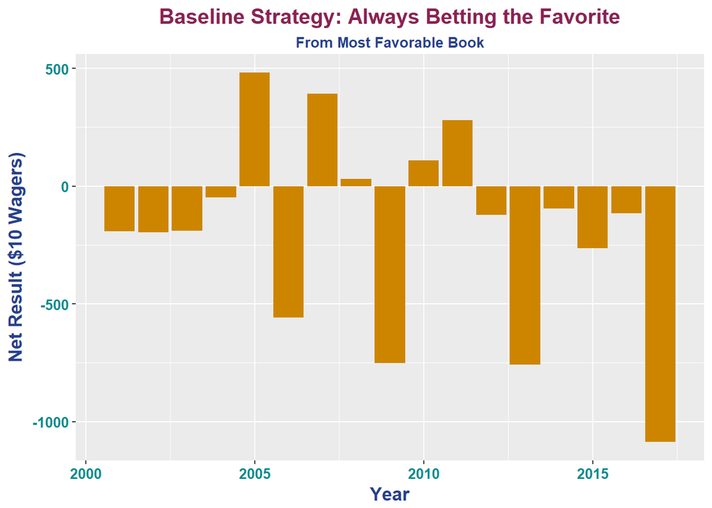

```r
Result <- rbind(df1, df2, df3, df4, df5, df6, df7, df8, df9, df10)
names(Result) <- c("Year","Strategy","Net Profit (w/ $10 bets)","# Successes","# Tries")

## Graph of Simulations
# theme
my.theme <- theme(axis.text.x=element_text(face="bold",color="cyan4", size=10), axis.text.y=element_text(face="bold",color="cyan4",size=10), axis.title = element_text(face="bold",color="royalblue4",size=13), plot.title = element_text(face="bold",color="violetred4",size=15,hjust=.5), legend.title=element_blank(), plot.subtitle = element_text(face="bold", color="royalblue4", size=10, hjust=.5))

# Favorite
ggplot(data=df6, aes(x=Year, y=Net)) + stat_summary(fun.y=mean, geom="bar", fill="orange3") + labs(x="Year", y="Net Result ($10 Wagers)", title="Baseline Strategy: Always Betting the Favorite", subtitle="From Most Favorable Book") + my.theme
```

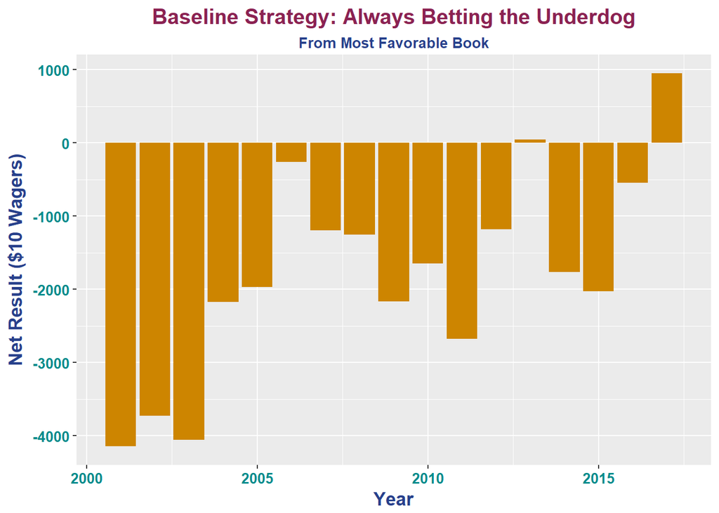

```r
# Underdog
ggplot(data=df7, aes(x=Year, y=Net)) + stat_summary(fun.y=mean, geom="bar", fill="orange3") + labs(x="Year", y="Net Result ($10 Wagers)", title="Baseline Strategy: Always Betting the Underdog", subtitle="From Most Favorable Book") + my.theme
```

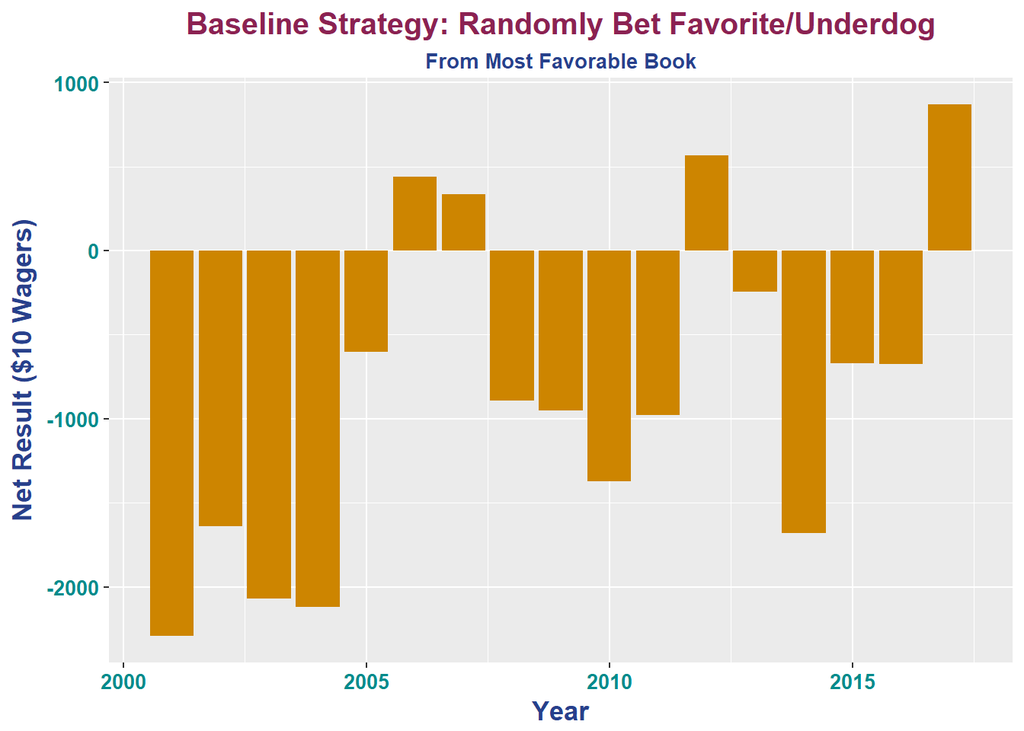

```r
# Random
ggplot(data=df8, aes(x=Year, y=Net)) + stat_summary(fun.y=mean, geom="bar", fill="orange3") + labs(x="Year", y="Net Result ($10 Wagers)", title="Baseline Strategy: Randomly Bet Favorite/Underdog", subtitle="From Most Favorable Book") + my.theme
```

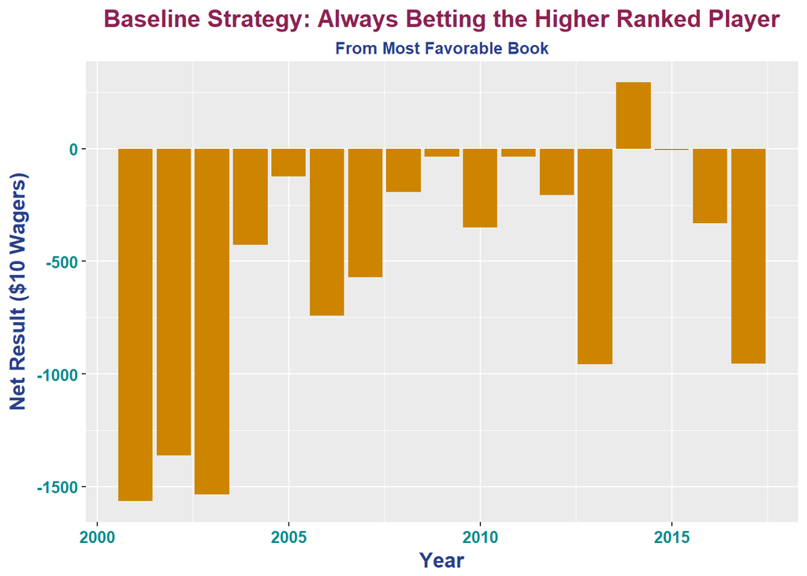

```r
# Higher Rank
ggplot(data=df9, aes(x=Year, y=Net)) + stat_summary(fun.y=mean, geom="bar", fill="orange3") + labs(x="Year", y="Net Result ($10 Wagers)", title="Baseline Strategy: Always Betting the Higher Ranked Player", subtitle="From Most Favorable Book") + my.theme
```

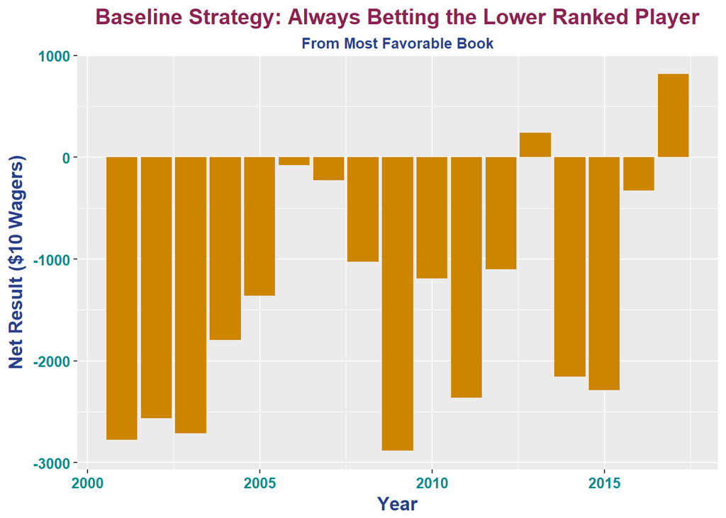

```r
# Lower Rank
ggplot(data=df10, aes(x=Year, y=Net)) + stat_summary(fun.y=mean, geom="bar", fill="orange3") + labs(x="Year", y="Net Result ($10 Wagers)", title="Baseline Strategy: Always Betting the Lower Ranked Player", subtitle="From Most Favorable Book") + my.theme
```

##### Comments on Results of Baseline Strategies

The ultimate conclusion from the baseline strategies: YOU CANNOT WIN WITH THEM… You will lose in the long run. However, betting the favorite is not quite as devastating as betting the underdog.

### Analysis

```r
### load in data
data <- load('data/favorite.data.RData')
data <- favorite.data


### Clean Data
# only include matches that sports books took bets on and don't include Round Robins
data <- data %>% filter((FcountOdds > 0) & (UcountOdds > 0) & Round != "Round Robin")

# new column for absolute rank difference variable: abs.rank.dif
data <- data %>% mutate(rank.dif = URank - FRank)

# new column for absolute odds difference variable: abs.odds.dif
data <- data %>% mutate(odds.dif = avgF - avgU)


### What is the raw probability of an upset?
sum(data$odds.upset/nrow(data))
```

```
## [1] 0.2996105
```

```r
#Upset occurs with probability .30... Hence, odds have a success rate p = .70


### Training data from 2001 through 2014
train <- data %>% filter(!(year %in% c("2015","2016","2017")))
test <- data %>% filter(year %in% c("2015","2016","2017"))


### Frequency Tables
# Row-proportions: Best.of vs. odds.upset
prop.table(table(train$Best.of, train$odds.upset),1)
```

```
##
##         FALSE      TRUE
##   3 0.6858752 0.3141248
##   5 0.7630312 0.2369688
```

```r
# Row-proportions: Surface vs. odds.upset
prop.table(table(train$Surface, train$odds.upset),1)
```

```
##
##              FALSE      TRUE
##   Carpet 0.6679894 0.3320106
##   Clay   0.6970159 0.3029841
##   Grass  0.7233533 0.2766467
##   Hard   0.7000874 0.2999126
```

```r
# Row-proportions: Round vs. odds.upset
prop.table(table(train$Round, train$odds.upset),1)
```

```
##
##                     FALSE      TRUE
##   1st Round     0.6915229 0.3084771
##   2nd Round     0.7143947 0.2856053
##   3rd Round     0.7157007 0.2842993
##   4th Round     0.7666151 0.2333849
##   Quarterfinals 0.6901173 0.3098827
##   Semifinals    0.6786306 0.3213694
##   The Final     0.6985539 0.3014461
```

```r
# Row-proportions: Series vs. odds.upset
prop.table(table(train$Series,train$odds.upset),1)
```

```
##
##                            FALSE      TRUE
##   ATP250               0.6878953 0.3121047
##   ATP500               0.7085689 0.2914311
##   Grand Slam           0.7630562 0.2369438
##   International        0.6826982 0.3173018
##   International Gold   0.6777743 0.3222257
##   International Series 0.6959799 0.3040201
##   Masters              0.6766545 0.3233455
##   Masters 1000         0.6953743 0.3046257
##   Masters Cup          0.7750000 0.2250000
```

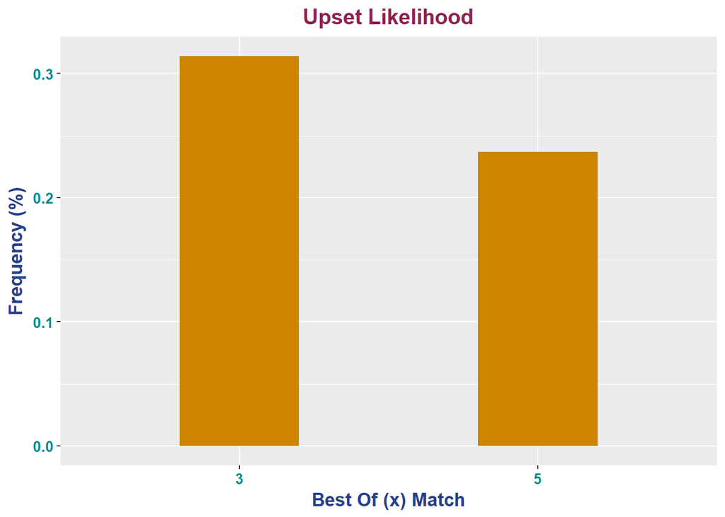

```r
### Frequency Bar Graphs
my.theme <- theme(axis.text.x=element_text(face="bold",color="cyan4", size=8, angle=30), axis.text.y=element_text(face="bold",color="cyan4",size=8), axis.title = element_text(face="bold",color="royalblue4",size=13), plot.title = element_text(face="bold",color="violetred4",size=15,hjust=.5))

# Frequency Bar Graph: Best.of vs. odds.upset
ggplot(data=train, aes(Best.of,as.numeric(odds.upset))) + stat_summary(fun.y=mean, geom="bar",fill="orange3",width=.4) + labs(y="Frequency (%)", x="Best Of (x) Match", title="Upset Likelihood") + theme(axis.text.x=element_text(face="bold",color="cyan4", size=10), axis.text.y=element_text(face="bold",color="cyan4",size=10), axis.title = element_text(face="bold",color="royalblue4",size=13), plot.title = element_text(face="bold",color="violetred4",size=15,hjust=.5))
```

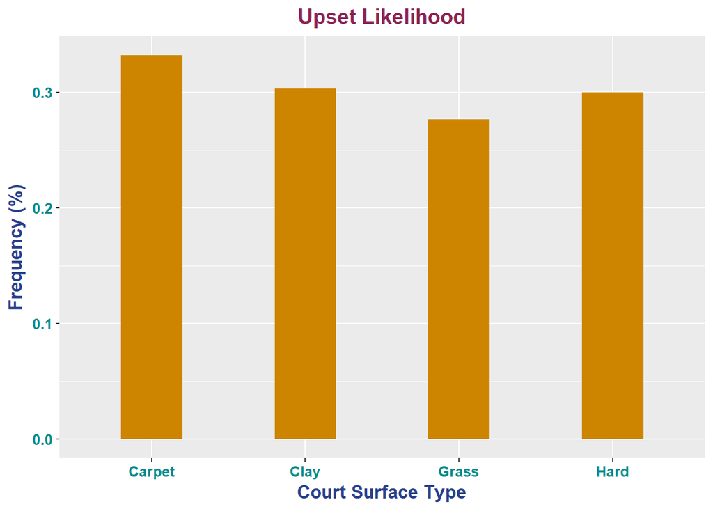

```r
# Frequency Bar Graph: Surface vs. odds.upset
ggplot(data=train, aes(Surface,as.numeric(odds.upset))) + stat_summary(fun.y=mean, geom="bar",fill="orange3",width=.4) + labs(y="Frequency (%)", x="Court Surface Type", title="Upset Likelihood") + theme(axis.text.x=element_text(face="bold",color="cyan4", size=10), axis.text.y=element_text(face="bold",color="cyan4",size=10), axis.title = element_text(face="bold",color="royalblue4",size=13), plot.title = element_text(face="bold",color="violetred4",size=15,hjust=.5))
```

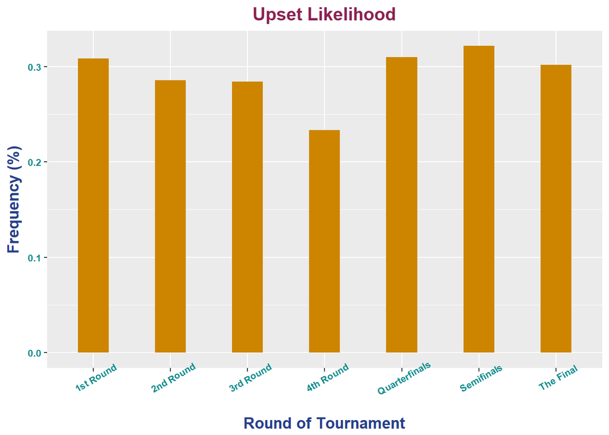

```r
# Frequency Bar Graph: Round vs. odds.upset
ggplot(data=train, aes(Round,as.numeric(odds.upset))) + stat_summary(fun.y=mean, geom="bar",fill="orange3",width=.4) + labs(y="Frequency (%)", x="Round of Tournament", title="Upset Likelihood") + my.theme
```

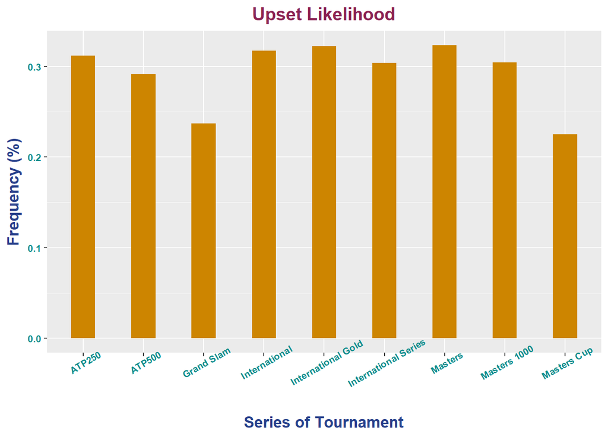

```r
# Frequency Bar Graph: Series vs. odds.upset
ggplot(data=train, aes(Series,as.numeric(odds.upset))) + stat_summary(fun.y=mean, geom="bar",fill="orange3",width=.4) + labs(y="Frequency (%)", x="Series of Tournament", title="Upset Likelihood") + my.theme
```

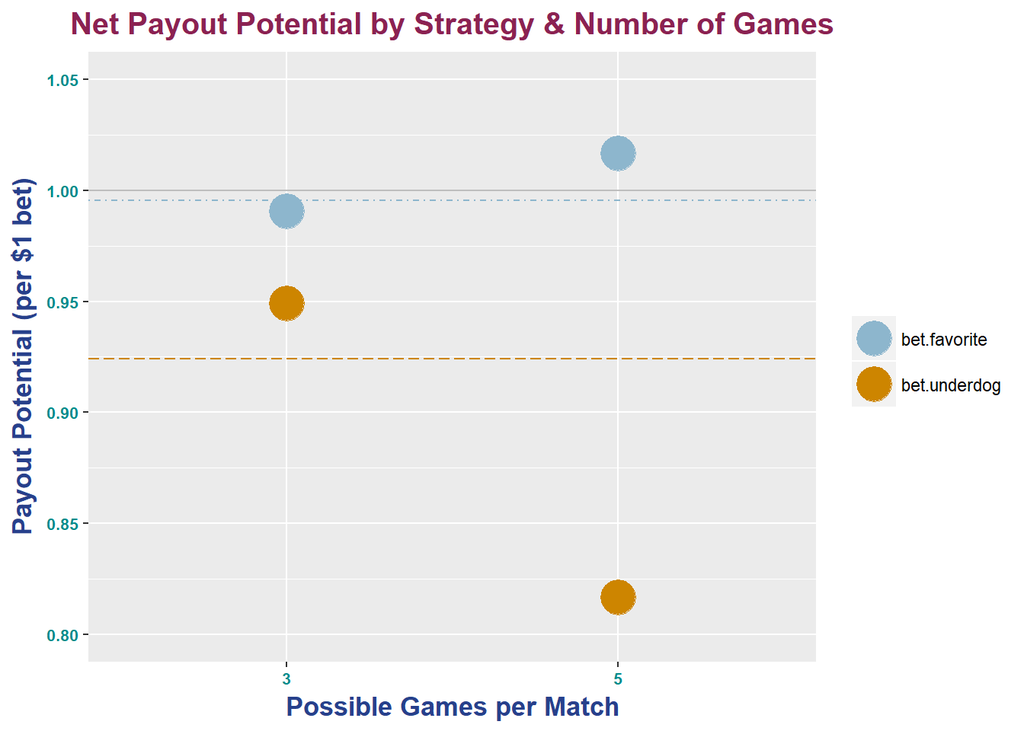

```r
### Graph Winning Potential
#### First, set up the data...
detach(package:plyr)
library(dplyr)

# Row-proportions: Best.of vs. odds.upset
df.bestof <- as.data.frame(prop.table(table(train$Best.of, train$odds.upset),1))
names(df.bestof) <- c("Best.of", "odds.upset", "upset.freq")
df.bestof <- df.bestof %>% filter(odds.upset == TRUE) %>% select(1,3)
t1<- train %>% group_by(Best.of) %>% filter(odds.upset==FALSE) %>% summarize(chalk.avg = mean(FMaxOdds))
t2<- train %>% group_by(Best.of) %>% filter(odds.upset==TRUE) %>% summarize(dog.avg = mean(UMaxOdds))
df.bestof$chalk.avg.odds <- as.data.frame(t1)[,2]
df.bestof$dog.avg.odds <- as.data.frame(t2)[,2]
df.bestof <- df.bestof %>% mutate(bet.favorite = (1-upset.freq)*chalk.avg.odds, bet.underdog = (upset.freq*dog.avg.odds))


# Row-proportions: Surface vs. odds.upset
df.surface <- as.data.frame(prop.table(table(train$Surface, train$odds.upset),1))
names(df.surface) <- c("Surface", "odds.upset", "upset.freq")
df.surface <- df.surface %>% filter(odds.upset == TRUE) %>% select(1,3)
t1<- train %>% group_by(Surface) %>% filter(odds.upset==FALSE) %>% summarize(chalk.avg = mean(FMaxOdds))
t2<- train %>% group_by(Surface) %>% filter(odds.upset==TRUE) %>% summarize(dog.avg = mean(UMaxOdds))
df.surface$chalk.avg.odds <- as.data.frame(t1)[,2]
df.surface$dog.avg.odds <- as.data.frame(t2)[,2]
df.surface <- df.surface %>% mutate(bet.favorite = (1-upset.freq)*chalk.avg.odds, bet.underdog = (upset.freq*dog.avg.odds))


# Row-proportions: Round vs. odds.upset
df.round <- as.data.frame(prop.table(table(train$Round, train$odds.upset),1))
names(df.round) <- c("Round", "odds.upset", "upset.freq")
df.round <- df.round %>% filter(odds.upset == TRUE) %>% select(1,3)
t1<- train %>% group_by(Round) %>% filter(odds.upset==FALSE) %>% summarize(chalk.avg = mean(FMaxOdds))
t2<- train %>% group_by(Round) %>% filter(odds.upset==TRUE) %>% summarize(dog.avg = mean(UMaxOdds))
df.round$chalk.avg.odds <- as.data.frame(t1)[,2]
df.round$dog.avg.odds <- as.data.frame(t2)[,2]
df.round <- df.round %>% mutate(bet.favorite = (1-upset.freq)*chalk.avg.odds, bet.underdog = (upset.freq*dog.avg.odds))


# Row-proportions: Series vs. odds.upset
df.series <- as.data.frame(prop.table(table(train$Series,train$odds.upset),1))
names(df.series) <- c("Series", "odds.upset", "upset.freq")
df.series <- df.series %>% filter(odds.upset == TRUE) %>% select(1,3)
t1<- train %>% group_by(Series) %>% filter(odds.upset==FALSE) %>% summarize(chalk.avg = mean(FMaxOdds))
t2<- train %>% group_by(Series) %>% filter(odds.upset==TRUE) %>% summarize(dog.avg = mean(UMaxOdds))
df.series$chalk.avg.odds <- as.data.frame(t1)[,2]
df.series$dog.avg.odds <- as.data.frame(t2)[,2]
df.series <- df.series %>% mutate(bet.favorite = (1-upset.freq)*chalk.avg.odds, bet.underdog = (upset.freq*dog.avg.odds))


# Average dog.proft & chalk.proft for horizontal lines
train.1 <- train %>% filter(odds.upset==FALSE)
train.2 <- train %>% filter(odds.upset==TRUE)
overall.chalk.profit <- mean(train.1$FMaxOdds)*mean(1-as.numeric(train$odds.upset))
overall.dog.profit <- mean(train.2$UMaxOdds)*mean(as.numeric(train$odds.upset))
df.bestof.1 <- gather(df.bestof,key="chalk.dog",value="profit",c(5,6))
df.round.1 <- gather(df.round,key="chalk.dog",value="profit",c(5,6))
df.surface.1 <- gather(df.surface,key="chalk.dog",value="profit",c(5,6))
df.series.1 <- gather(df.series,key="chalk.dog",value="profit",c(5,6))
names(df.bestof) <- c("Best.of","upset.freq","fav.avg.odds","dog.avg.odds","fav.potential","dog.potential")
names(df.round) <- c("Round","upset.freq","fav.avg.odds","dog.avg.odds","fav.potential","dog.potential")
names(df.surface) <- c("Surface","upset.freq","fav.avg.odds","dog.avg.odds","fav.potential","dog.potential")
names(df.series) <- c("Series","upset.freq","fav.avg.odds","dog.avg.odds","fav.potential","dog.potential")



#### Payout-Potential Graphs
# theme
my.theme <- theme(axis.text.x=element_text(face="bold",color="cyan4", size=8, angle=30), axis.text.y=element_text(face="bold",color="cyan4",size=8), axis.title = element_text(face="bold",color="royalblue4",size=13), plot.title = element_text(face="bold",color="violetred4",size=15,hjust=.5), legend.title=element_blank())

# color pallete
my.colors <- as.character(c("chalk.profit"="lightskyblue3", "dog.profit"="orange3"))
my.color.scale <- scale_colour_manual(name="my.colors", values=my.colors)


# Best OF
ggplot(data=df.bestof.1, aes(x=Best.of, y=profit)) + geom_point(aes(color = chalk.dog),size=8) + my.color.scale + geom_hline(yintercept = overall.dog.profit, linetype = "longdash", color = "orange3") + geom_hline(yintercept = overall.chalk.profit, linetype = "dotdash", color = "lightskyblue3") + geom_hline(yintercept=1, color = "grey") + labs(title ="Net Payout Potential by Strategy & Number of Games", y="Payout Potential (per $1 bet)", x = "Possible Games per Match") + theme(axis.text.x=element_text(face="bold",color="cyan4", size=8), axis.text.y=element_text(face="bold",color="cyan4",size=8), axis.title = element_text(face="bold",color="royalblue4",size=13), plot.title = element_text(face="bold",color="violetred4",size=15,hjust=.5), legend.title=element_blank()) + geom_text(x = 3.3, y = .925, label = "Overall Underdog", size = 3) + geom_text(x=3.3, y=.995, label = "Overall Favorite", size = 3) + scale_y_continuous(limits = c(.8,1.05), breaks = seq(.8,1.1,.05))
```

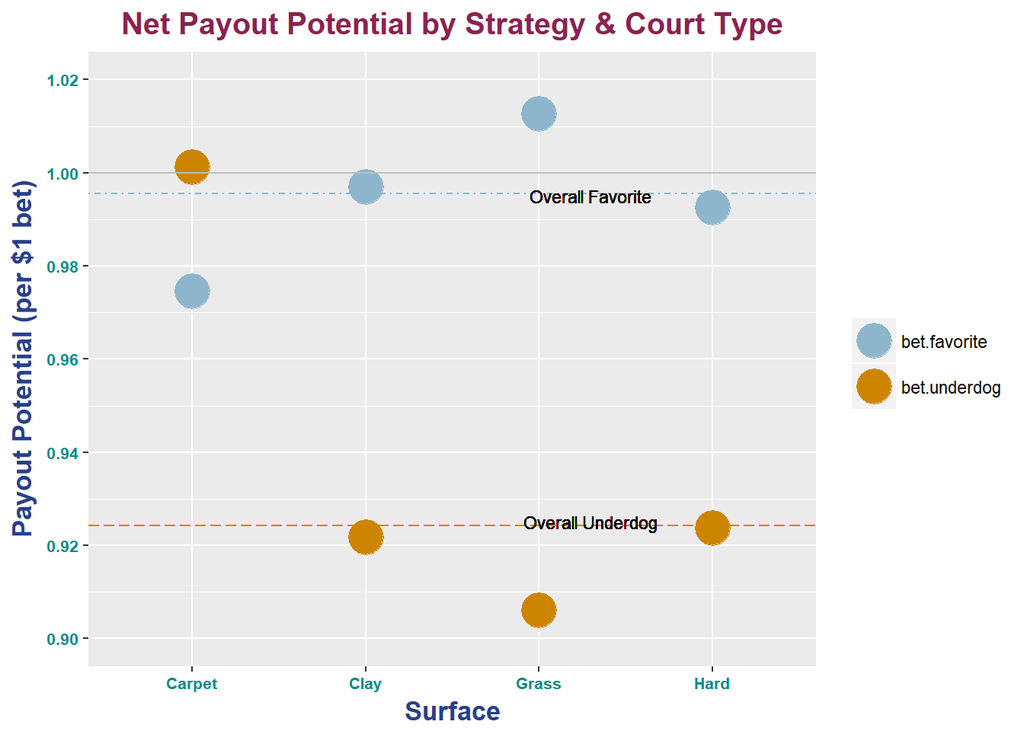

```r
# SURFACE
ggplot(data=df.surface.1, aes(x=Surface, y=profit)) + geom_point(aes(color = chalk.dog),size=8) + my.color.scale + geom_hline(yintercept = overall.dog.profit, linetype = "longdash", color = "orange3") + geom_hline(yintercept = overall.chalk.profit, linetype = "dotdash", color = "lightskyblue3") + geom_hline(yintercept=1, color = "grey") + labs(title ="Net Payout Potential by Strategy & Court Type", y="Payout Potential (per $1 bet)", x = "Surface") + theme(axis.text.x=element_text(face="bold",color="cyan4", size=8), axis.text.y=element_text(face="bold",color="cyan4",size=8), axis.title = element_text(face="bold",color="royalblue4",size=13), plot.title = element_text(face="bold",color="violetred4",size=15,hjust=.5), legend.title=element_blank()) + geom_text(x = 3.3, y = .925, label = "Overall Underdog", size = 3) + geom_text(x=3.3, y=.995, label = "Overall Favorite", size = 3) + scale_y_continuous(limits = c(.9,1.02), breaks = seq(.9,1.2,.02))
```

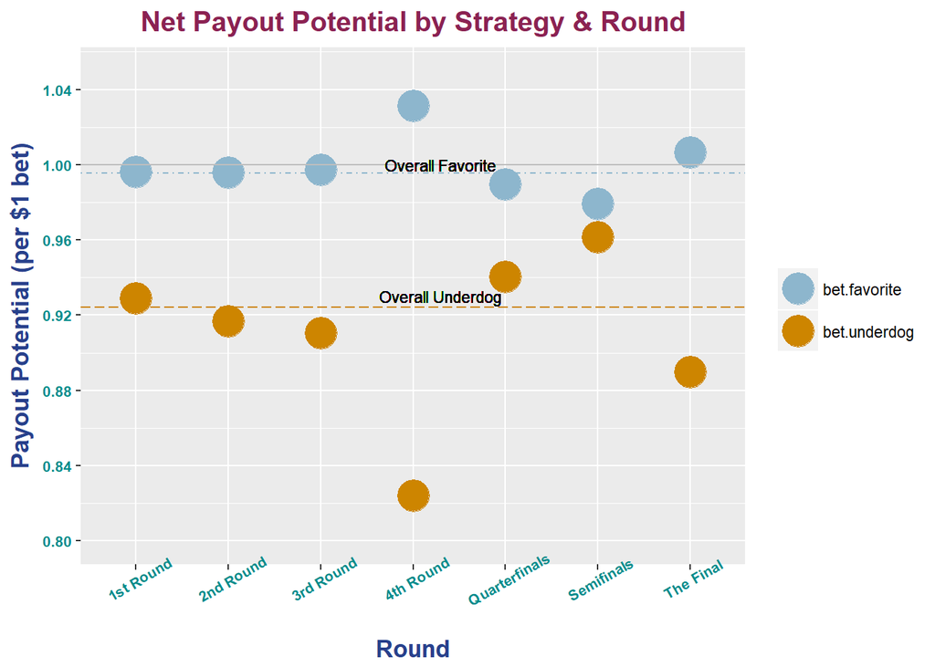

```r
# ROUND
ggplot(data=df.round.1, aes(x=Round, y=profit)) + geom_point(aes(color = chalk.dog),size=8) + my.color.scale + geom_hline(yintercept = overall.dog.profit, linetype = "longdash", color = "orange3") + geom_hline(yintercept = overall.chalk.profit, linetype = "dotdash", color = "lightskyblue3") + geom_hline(yintercept=1, color = "grey") + labs(title ="Net Payout Potential by Strategy & Round", y="Payout Potential (per $1 bet)", x = "Round") + my.theme + geom_text(x = 4.3, y = .93, label = "Overall Underdog", size = 3) + geom_text(x=4.3, y=1, label = "Overall Favorite", size = 3) + scale_y_continuous(limits = c(.8,1.05), breaks = seq(.8,1.5,.04))
```

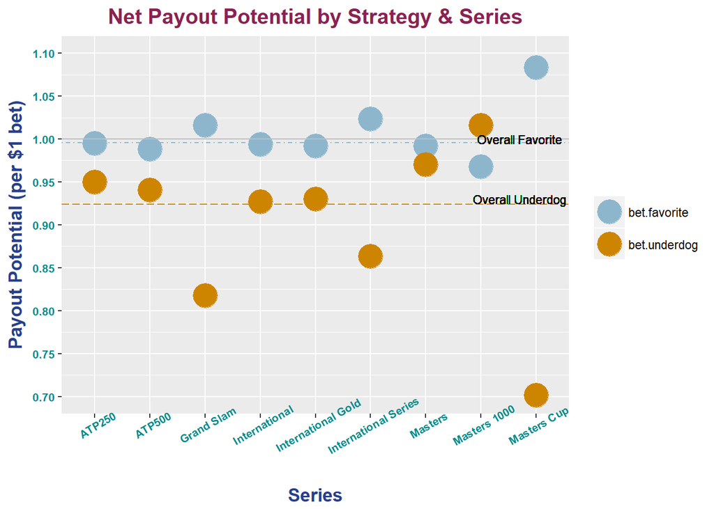

```r
# SERIES
ggplot(data=df.series.1, aes(x=Series, y=profit)) + geom_point(aes(color = chalk.dog),size=8) + my.color.scale + geom_hline(yintercept = overall.dog.profit, linetype = "longdash", color = "orange3") + geom_hline(yintercept = overall.chalk.profit, linetype = "dotdash", color = "lightskyblue3") + geom_hline(yintercept=1, color = "grey") + labs(title ="Net Payout Potential by Strategy & Series", y="Payout Potential (per $1 bet)", x = "Series") + my.theme + geom_text(x = 8.7, y = .93, label = "Overall Underdog", size = 3) + geom_text(x=8.7, y=1, label = "Overall Favorite", size = 3) + scale_y_continuous(limits = c(.7,1.10), breaks = seq(.7,1.10,.05))
```

# Gambling Strategy Simulation

## Strategy based on Payout-Potential Measure

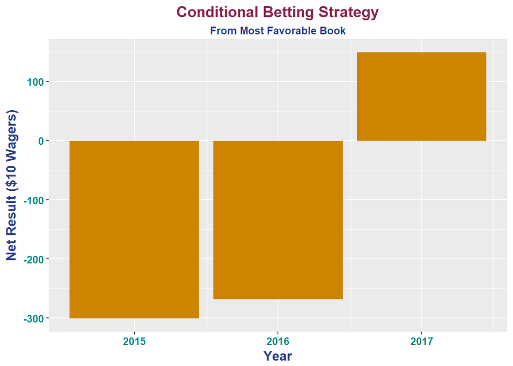

```r
### Payout-Potenial Strategy Function
nick.strategy <- function(df, wager = 10){

  # initialize
  net <- 0
  tries <- 0
  wins <- 0

  # Vector of decision requirements - series
  bet.fav.series <- c("Grand Slam", "International Series", "Masters Cup")
  bet.dog.series <- c("Masters 1000")
  # Vector of baseline betting requirements - series
  bet.series <- c(bet.fav.series, bet.dog.series, "ATP250", "ATP500", "Masters")

  # Vector of decision requirements - game
  bet.fav.games <- c(5)
  bet.dog.games <- c()
  # Vector of baseline betting requirements - game
  bet.games <- c(bet.fav.games, 3)

  # Vector of decision requirements - surface
  bet.fav.surface <- c("Grass")
  bet.dog.surface <- c("Carpet")
  # Vector of baseline betting requirements - surface
  bet.surface <- c(bet.fav.surface, bet.dog.surface, "Hard", "Clay")

  # Vector of decision requirements - round
  bet.fav.round <- c("4th Round", "The Final")
  bet.dog.round <- c()
  # Vector of baseline betting requirements - round
  bet.round <- c(bet.fav.round,"Quarterfinals", "Semifinals")


  # Loop for betting decisions
  for(i in 1:nrow(df)){

    # Match must meet all baseline betting requirements
    if((df$Series[i] %in% bet.series) & (df$Best.of[i] %in% bet.games) & (df$Surface[i] %in% bet.surface) & (df$Round[i] %in% bet.round)){


      # BET UNDERDOG if any underdog decision requirement met
      if((df$Series[i] %in% bet.dog.series) | (df$Best.of[i] %in% bet.dog.games) | (df$Surface[i] %in% bet.dog.surface) | (df$Round[i] %in% bet.dog.round)){

        # place wager on UMaxOdds

        # if win
        if(df$odds.upset[i] == TRUE){
          bet.result <- wager * (df$UMaxOdds[i]-1)

          net <- net + bet.result
          wins <- wins + 1
          tries <- tries + 1
        }

        #if loss
        if(df$odds.upset[i] == FALSE){
          bet.result <- -1*wager

          net <- net + bet.result
          tries <- tries + 1
        }
      }

      # BET FAVORITE if any favorite decision requirement met
      else if((df$Series[i] %in% bet.fav.series) | (df$Best.of[i] %in% bet.fav.games) | (df$Surface[i] %in% bet.fav.surface) | (df$Round[i] %in% bet.fav.round)){

        # place wager on FMaxOdds

        # if win
        if(df$odds.upset[i] == FALSE){
          bet.result <- wager * (df$FMaxOdds[i]-1)

          net <- net + bet.result
          wins <- wins + 1
          tries <- tries + 1
        }

        #if loss
        if(df$odds.upset[i] == TRUE){
          bet.result <- -1*wager

          net <- net + bet.result
          tries <- tries + 1
        }
      }
    }
  }

  # RETURN LIST
  out <- list(net, wins, tries)
  names(out) <- c("net","wins","tries")
  return(out)
}



### Loop simulation through 2015, 2016, 2017
YEARS <- unique(test$year)
Net <- rep(NA, times=3)
Wins <- rep(NA, times=3)
Tries <- rep(NA, times=3)

sim <- data.frame(YEARS, Net, Wins, Tries)

for(i in 1:length(YEARS)){
  season <- test %>% filter(year == YEARS[i])
  s.result <- nick.strategy(season, wager = 10)

  sim$Net[i] <- s.result[[1]]
  sim$Wins[i] <- s.result[[2]]
  sim$Tries[i] <- s.result[[3]]
}
names(sim)[1] <- "Year"

## Graph of Simulation Results
# theme
my.theme <- theme(axis.text.x=element_text(face="bold",color="cyan4", size=10), axis.text.y=element_text(face="bold",color="cyan4",size=10), axis.title = element_text(face="bold",color="royalblue4",size=13), plot.title = element_text(face="bold",color="violetred4",size=15,hjust=.5), legend.title=element_blank(), plot.subtitle = element_text(face="bold", color="royalblue4", size=10, hjust=.5))

# ggplot
ggplot(data=sim, aes(x=Year, y=Net)) + stat_summary(fun.y=mean, geom="bar", fill="orange3") + labs(x="Year", y="Net Result ($10 Wagers)", title="Conditional Betting Strategy", subtitle="From Most Favorable Book") + my.theme
```

### Single Player Logistic Regression

```r
#data cleaning for regression
t2 <- subset(total,select=-c(length(total), length(total) - 1, length(total) - 2, length(total) - 3))

avgW <- rep(NA,nrow(t2))
avgL <- rep(NA,nrow(t2))
t2$avgW <- avgW
t2$avgL <- avgL
for(i in 1:nrow(total)){
  t2$avgW[i] <- mean(c(t2$CBW[i], t2$GBW[i], t2$IWW[i], t2$SBW[i], t2$B365W[i], t2$B.WW[i], t2$EXW[i], t2$PSW[i], t2$UBW[i], t2$LBW[i], t2$SJW[i]), na.rm = TRUE)
  t2$avgL[i] <- mean(c(t2$CBL[i], t2$GBL[i], t2$IWL[i], t2$SBL[i], t2$B365L[i], t2$B.WL[i], t2$EXL[i], t2$PSL[i], t2$UBL[i], t2$LBL[i], t2$SJL[i]), na.rm = TRUE)
}


save(t2, file = "aggregated_mens_logistic.RData")
```

### Logistic Regression Simulation

```r
#load mens data and format dates column
men.data <- t2
#format date column
dates <- mdy(men.data$Date)
men.data$Date <- dates
#convert variables to numeric and factors
men.data$LRank <- as.numeric(men.data$LRank)
men.data$WRank <- as.numeric(men.data$WRank)
men.data$LPts <- as.numeric(men.data$LPts)
men.data$WPts <- as.numeric(men.data$WPts)
men.data$Surface <- as.factor(men.data$Surface)
men.data$Round <- as.factor(men.data$Round)
men.data$Series <- as.factor(men.data$Series)
men.data$Best.of <- as.factor(men.data$Best.of)

  #remove rows with NaN in average betting odds columns, rank columns, and point columns
  men.data <- men.data[!is.na(men.data$avgW),]
  men.data <- men.data[!is.na(men.data$avgL),]
  men.data <- men.data[!is.na(men.data$avgW),]
  men.data <- men.data[!is.na(men.data$avgL),]
  men.data <- men.data[!is.na(men.data$WRank),]
  men.data <- men.data[!is.na(men.data$LRank),]
  men.data <- men.data[!is.na(men.data$WRank),]
  men.data <- men.data[!is.na(men.data$LRank),]
  men.data <- men.data[!is.na(men.data$WPts),]
  men.data <- men.data[!is.na(men.data$LPts),]
  men.data <- men.data[!is.na(men.data$WPts),]
  men.data <- men.data[!is.na(men.data$LPts),]
```

A potential betting strategy that could work effectively is to be selective in the matches that you bet on, and only bet when you believe that the player has a very high probability of winning the match. A way to do this is use a logistic regression model for a given player and only bet if the model predicts that they have at least a certain probability of winning given different variables such as surface type, rank difference, and odds.

Below I create a function that simulates betting on the 2015, 2016, and 2017 seasons for a given player and runs a logistic regression model that predicts the probability of the given player of winning the match. The logistic regression model uses the 2001 to 2014 seasons as training data for each player. We will use the logistic regression model to look at different net payoffs if the minimum threshold for the winning probability in our betting strategy is changed.

```r
#function that simulates betting on 2015,2016, and 2017 seasons for a given player and runs a logistic regression to predict probability the player wins the match

player.logistic.simulation <- function(playerName, wager=10){
  #filter data frame to games containing a specific player and seperate into training & testing data
  player.train <- filter(men.data, (Winner %in% playerName | Loser %in% playerName) & Date <= "2014-12-31")
  player.test <- filter(men.data, (Winner %in% playerName | Loser %in% playerName) & Date >="2014-12-31")

  #create variable with outcome of game for player
  player.train$Outcome <- (player.train$Winner == playerName)
  player.train$Outcome <- as.numeric(player.train$Outcome)
  player.test$Outcome <- (player.test$Winner == playerName)
  player.test$Outcome <- as.numeric(player.test$Outcome)

  #create variable for odds, rank difference, and point difference of player in both testing and training data frames
  for(i in 1:dim(player.train)[1]){
    if(((player.train$Outcome[i] == 1))){
    player.train$Odds[i] <- player.train$avgW[i]
    player.train$RankDif[i] <- player.train$WRank[i]-player.train$LRank[i]
    player.train$PtDif[i] <- player.train$WPts[i] -player.train$LPts[i]
  }
    else{
    player.train$Odds[i] <- player.train$avgL[i]
    player.train$RankDif[i] <- player.train$LRank[i]-player.train$WRank[i]
    player.train$PtDif[i] <- -1*player.train$WPts[i] +player.train$LPts[i]
  }
}
  for(i in 1:dim(player.test)[1]){
    if(((player.test$Outcome[i] == 1))){
      player.test$Odds[i] <- player.test$avgW[i]
      player.test$RankDif[i] <- player.test$WRank[i]-player.test$LRank[i]
      player.test$PtDif[i] <- player.test$WPts[i] -player.test$LPts[i]
    }
    else{
      player.test$Odds[i] <- player.test$avgL[i]
      player.test$RankDif[i] <- player.test$LRank[i]-player.test$WRank[i]
      player.test$PtDif[i] <- -1*player.test$WPts[i] +player.test$LPts[i]
    }
  }



  #create logistic regression model using training data
  player.glm <- bayesglm(Outcome ~ Surface+Odds+RankDif+Best.of+Series+PtDif, family=binomial, data=player.train,drop.unused.levels   = FALSE)

  #format testing data to be able to input into predict.glm
  player.test <- subset(player.test, select=c("year","Surface","Odds","Outcome","Series","RankDif","PtDif","Best.of"))
  prob.win <- predict.glm(player.glm, newdata=subset(player.test,select=c("Surface","Odds","Series","RankDif","PtDif","Best.of")),type = "response")


  #attach predicted probability of winning
  player.test$prob <- as.numeric(prob.win)
  player.test$year <- as.factor(player.test$year)

  #payoff of match if we bet
  player.test <- mutate(player.test, payoff= Outcome*wager*(Odds-1))
  player.test$payoff[player.test$Outcome==0] <- -1*wager

  player.summary <- summary(player.glm)


  #output information regarding betting simulation
  out <- player.test
  return(out)
  }
```

Since the model is based solely on historic performance, it will only work effectively on players who have a larger history for the model to be based on. Therefore, I will run the simulation on all players in the current top 15 who are ages 29 and above. Below I run the simulation for these players and display the results of the simulations for if I had only bet on games in which the player had at least a 0.85, 0.875, or 0.9 probability of winning from the logistic regression’s predictions.

```r
#display information for simulation with minimum =0.85
df.85
```

```
##                              Net Wins Tries Win Percentage
## Rafael Nadal          -37.150000   97   111      0.8738739
## Roger Federer           6.062500   91    98      0.9285714
## Novak Djokovic         -1.496667  151   162      0.9320988
## Stan Wawrinka          27.008333   28    28      1.0000000
## Juan Martin del Potro  -5.400000   14    17      0.8235294
## Marin Cilic           -27.950000   29    35      0.8285714
## Sam Querrey            31.800000    4     4      1.0000000
## Kevin Anderson          1.575000   12    14      0.8571429
## Jo-Wilfried Tsonga     -4.025000   27    30      0.9000000
## Total                  -9.575833  453   499      0.9078156
```

```r
year.net.85
```

```
## # A tibble: 3 x 2
##     year       net
##   <fctr>     <dbl>
## 1   2015  52.26500
## 2   2016 -19.51583
## 3   2017 -42.32500
```

```r
#display information for simulation with minimum =0.875
df.875
```

```
##                               Net Wins Tries Win Percentage
## Rafael Nadal          -12.2750000   88    98      0.8979592
## Roger Federer          -0.1958333   83    89      0.9325843
## Novak Djokovic         -6.3300000  134   143      0.9370629
## Stan Wawrinka          12.6083333   16    16      1.0000000
## Juan Martin del Potro  -4.5000000   11    13      0.8461538
## Marin Cilic             6.2250000   18    19      0.9473684
## Sam Querrey            31.8000000    4     4      1.0000000
## Kevin Anderson          1.5750000   12    14      0.8571429
## Jo-Wilfried Tsonga      2.4750000   25    27      0.9259259
## Total                  31.3825000  391   423      0.9243499
```

```r
year.net.875
```

```
## # A tibble: 3 x 2
##     year       net
##   <fctr>     <dbl>
## 1   2015 38.990000
## 2   2016 -6.565833
## 3   2017 -1.041667
```

```r
#display information for simulation with minimum =0.9
df.9
```

```
##                              Net Wins Tries Win Percentage
## Rafael Nadal          -23.408333   80    89      0.8988764
## Roger Federer          -8.345833   68    73      0.9315068
## Novak Djokovic        -17.671667   93    99      0.9393939
## Stan Wawrinka           3.958333    6     6      1.0000000
## Juan Martin del Potro  -0.050000    6     7      0.8571429
## Marin Cilic             7.625000    8     8      1.0000000
## Sam Querrey            26.725000    2     2      1.0000000
## Kevin Anderson          5.450000    9    10      0.9000000
## Jo-Wilfried Tsonga      2.075000   16    17      0.9411765
## Total                  -3.642500  288   311      0.9260450
```

```r
year.net.9
```

```
## # A tibble: 3 x 2
##     year        net
##   <fctr>      <dbl>
## 1   2015  19.165000
## 2   2016 -17.365833
## 3   2017  -5.441667
```

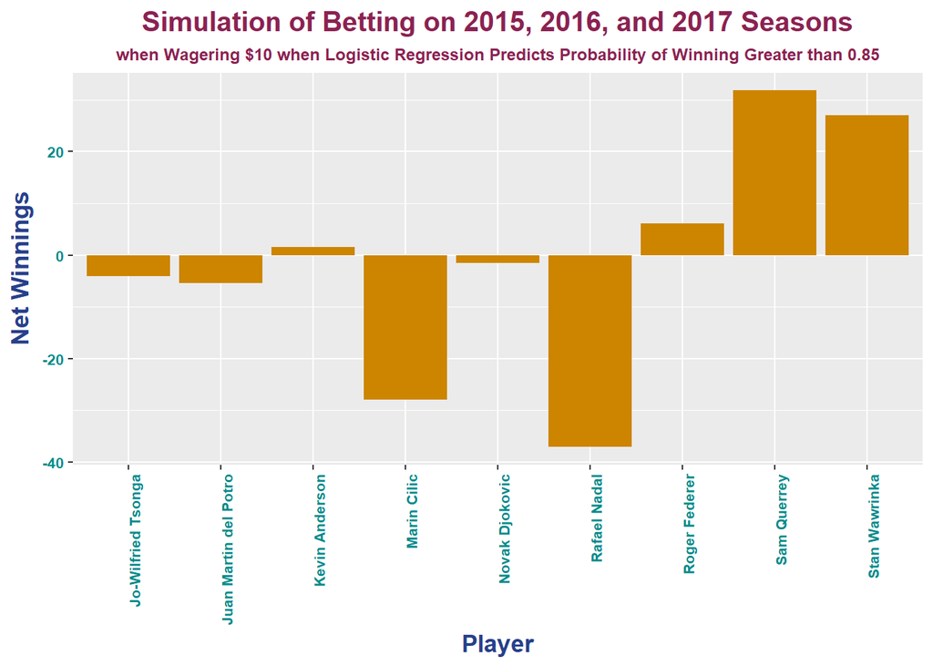

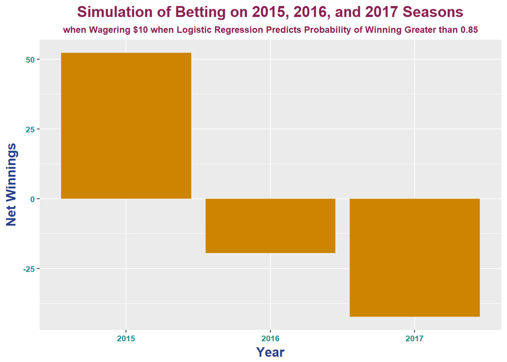

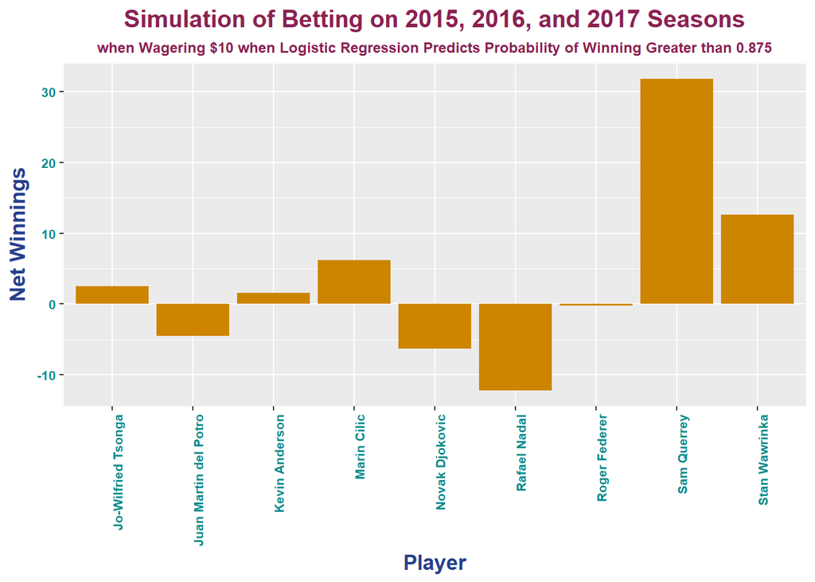

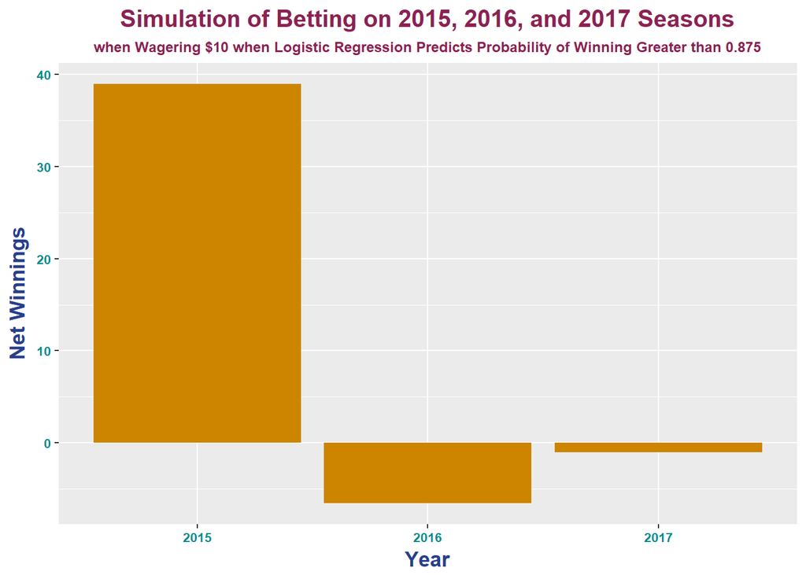

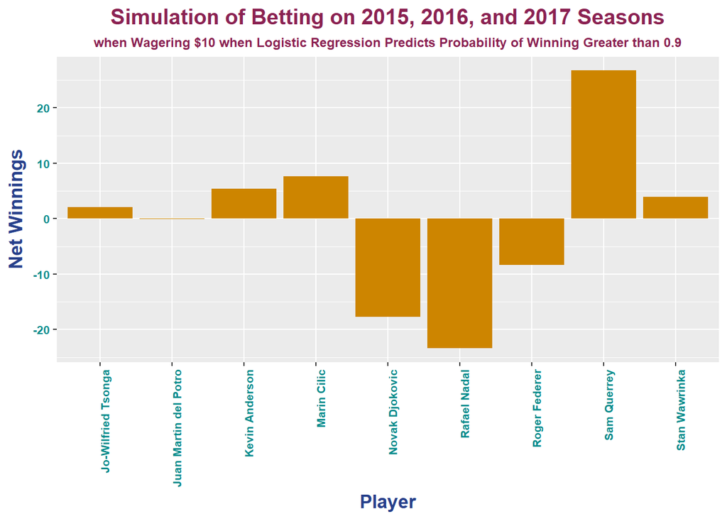

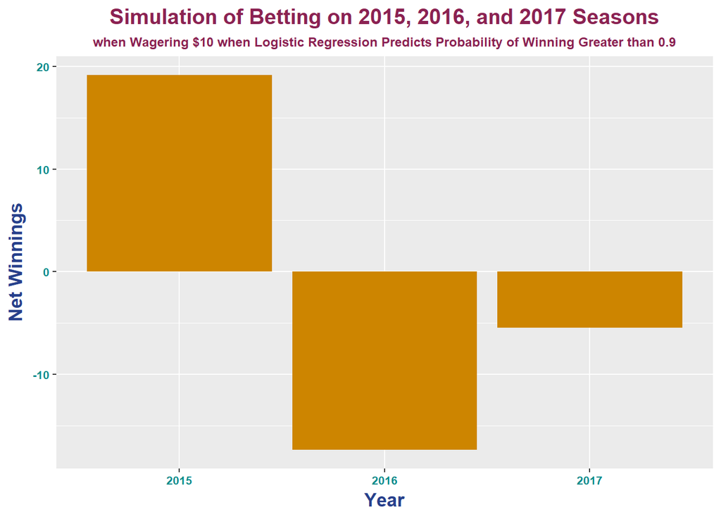

With this betting strategy, a new loss occurred when setting the probability minimum probability of winning a match for matches we would bet on at 0.85 and 0.9. A profit of $31.3825 was won on on 423 bets when the minimum probability was set at 0.875. The model predicts the outcome of the matches fairly accurately as seen in the win percentages of the data frames above. This accurate prediction of the probability of winning does not translate to net winnings that are very high because you are most likely placing bets when the payoff for being correct is not that high. Therefore, even if your bet is wrong only a small percentage of the time as it is above, the loss of your wager for these few incorrect bets is close to the amount of gain you have from all of your correct predictions. This also shows that always betting on the favorite or those who are ranked higher will not work. There will sometimes be matches in which a heavily favored player loses, so betting on safe matches will not work effectively. Being risk averse and only betting on the safe matches does not translate to winnings.

# Machine Learning: Advanced Models

```r
detach("package:arm", character.only = TRUE)
detach("package:MASS", character.only = TRUE)
```

## load Data

```r
load("data/favorite.data.RData")
men.data <- favorite.data
```

View Data Structure

```r
str(men.data)
```

```
## 'data.frame':    45740 obs. of  46 variables:
##  $ ATP        : int  1 1 1 1 1 1 1 1 1 1 ...
##  $ Location   : chr  "Adelaide" "Adelaide" "Adelaide" "Adelaide" ...
##  $ Tournament : chr  "AAPT Championships" "AAPT Championships" "AAPT Championships" "AAPT Championships" ...
##  $ Series     : chr  "International" "International" "International" "International" ...
##  $ Court      : chr  "Outdoor" "Outdoor" "Outdoor" "Outdoor" ...
##  $ Surface    : chr  "Hard" "Hard" "Hard" "Hard" ...
##  $ Round      : chr  "1st Round" "1st Round" "2nd Round" "2nd Round" ...
##  $ Best.of    : Factor w/ 2 levels "3","5": 1 1 1 1 1 1 1 1 1 1 ...
##  $ year       : num  2001 2001 2001 2001 2001 ...
##  $ maxWinOdds : num  1.12 1.28 1.35 1.13 2.7 1.55 2.3 1.47 2 1.41 ...
##  $ minLoseOdds: num  3.5 3.3 2.6 5.5 1.41 2 1.5 2.2 1.61 2.1 ...
##  $ date.new   : Date, format: "2001-01-01" "2001-01-01" ...
##  $ rank.upset : logi  FALSE FALSE FALSE FALSE TRUE FALSE ...
##  $ maxProfit  : num  0.12 0.28 0.35 0.13 1.7 ...
```

[output cut: 32 more lines]

## Impute Data

Imputing data replaces any null values. This is necessary for some models that will break when encountering nulls.

```r
#create new dataframe to impute
imputed.data <- men.data

#add favorite_won column used to predict winner
imputed.data$favorite_won <- as.factor(!imputed.data$odds.upset)

#Convert characters to factors
character.columns <- c("Location", "Tournament", "Series", "Surface", "Court","Round" )
for(col.name in character.columns){
  imputed.data[[col.name]]<- as.factor(imputed.data[[col.name]])
}

#List of odds books columns
favorite.columns <- c("B365F", "B.WF" , "CBF" , "EXF" , "LBF" , "GBF" , "IWF" , "PSF" , "SBF" , "SJF" , "UBF" )
underdog.columns <- c("B365U", "B.WU" , "CBU" , "EXU" , "LBU" , "GBU" , "IWU" , "PSU" , "SBU" , "SJU" , "UBU")

#replace all null value books with the average over all books for that match
for(col.name in favorite.columns){
  imputed.data[[col.name]][is.na(imputed.data[[col.name]])] <- imputed.data[["avgF"]][is.na(imputed.data[[col.name]])]
}
for(col.name in underdog.columns){
  imputed.data[[col.name]][is.na(imputed.data[[col.name]])] <- imputed.data[["avgU"]][is.na(imputed.data[[col.name]])]
}

#remove any remaining null values, and grab only the columns that we can use in our models
imputed.data <- imputed.data %>% na.omit() %>% select(-maxWinOdds, -minLoseOdds, -maxProfit, -rank.upset, -odds.upset, -Tournament, -Location)
#create a column for rank difference
imputed.data <- imputed.data %>% mutate(rank.diff = abs( URank - FRank))

#view structure of final imputed data
str(imputed.data)
```

```
## 'data.frame':    45641 obs. of  41 variables:
##  $ ATP         : int  1 1 1 1 1 1 1 1 1 1 ...
##  $ Series      : Factor w/ 9 levels "ATP250","ATP500",..: 4 4 4 4 4 4 4 4 4 4 ...
##  $ Court       : Factor w/ 2 levels "Indoor","Outdoor": 2 2 2 2 2 2 2 2 2 2 ...
##  $ Surface     : Factor w/ 4 levels "Carpet","Clay",..: 4 4 4 4 4 4 4 4 4 4 ...
##  $ Round       : Factor w/ 8 levels "1st Round","2nd Round",..: 1 1 2 2 2 2 5 5 5 5 ...
##  $ Best.of     : Factor w/ 2 levels "3","5": 1 1 1 1 1 1 1 1 1 1 ...
##  $ year        : num  2001 2001 2001 2001 2001 ...
##  $ date.new    : Date, format: "2001-01-01" "2001-01-01" ...
##  $ B365F       : num  1.11 1.2 1.28 1.13 1.43 ...
##  $ B.WF        : num  1.11 1.2 1.28 1.13 1.43 ...
##  $ CBF         : num  1.11 1.28 1.35 1.13 1.42 1.55 1.53 1.4 1.7 1.35 ...
##  $ EXF         : num  1.11 1.2 1.28 1.13 1.43 ...
##  $ LBF         : num  1.11 1.2 1.28 1.13 1.43 ...
##  $ GBF         : num  1.12 1.12 1.2 1.13 1.41 ...
```

[output cut: 27 more lines]

Theme for plots

```r
# theme
my.theme <- theme(axis.text.x=element_text(face="bold",color="cyan4", size=10), axis.text.y=element_text(face="bold",color="cyan4",size=10), axis.title = element_text(face="bold",color="royalblue4",size=13), plot.title = element_text(face="bold",color="violetred4",size=15,hjust=.5), legend.title=element_blank(), plot.subtitle = element_text(face="bold", color="royalblue4", size=10, hjust=.5))
```

```r
#Function for plotting winnings over time
plot.winnings <- function(df, title){
  df.new.pred <- df %>% dplyr::filter(is.finite(winnings)) %>% arrange(date.new) %>% mutate(winnings = cumsum(winnings))
  plot.df <- ggplot(df.new.pred, aes(date.new, winnings))  + geom_line(color='orange3', size=1) + xlab("Date") + ylab("Winnings") + ggtitle(title)

  print(plot.df)
}
```

# Use Models to classify whether winner was the favorite or underdog

```
## [1] "2011-01-01"
```

```
## [1] "reg"
##
##                       FALSE TRUE
##   False: Underdog Won    84  658
##   True: Favorite Won    109 1813
## [1] "accuracy:  0.712087087087087"
## [1] "svm"
##
##                       FALSE TRUE
##   False: Underdog Won     0  742
##   True: Favorite Won      0 1922
## [1] 0.7214715
## [1] "rf"
##
##                       FALSE TRUE
##   False: Underdog Won   144  598
##   True: Favorite Won    246 1676
## [1] 0.6831832
## [1] "boost"
##
##                       FALSE TRUE
##   False: Underdog Won   143  599
##   True: Favorite Won    225 1697
## [1] "accuracy:  0.690690690690691"
##
##                       FALSE TRUE
##   False: Underdog Won   143  599
##   True: Favorite Won    225 1697
```

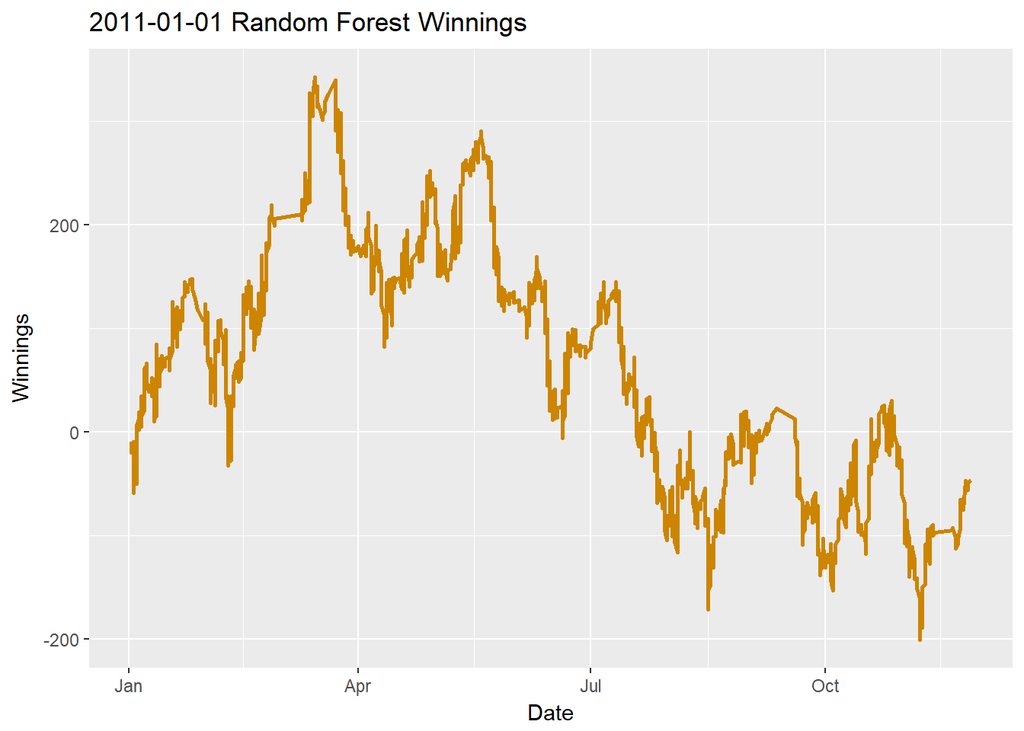

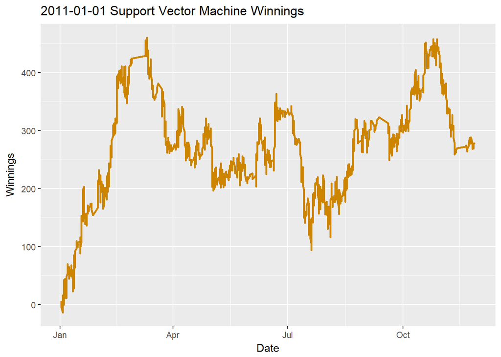

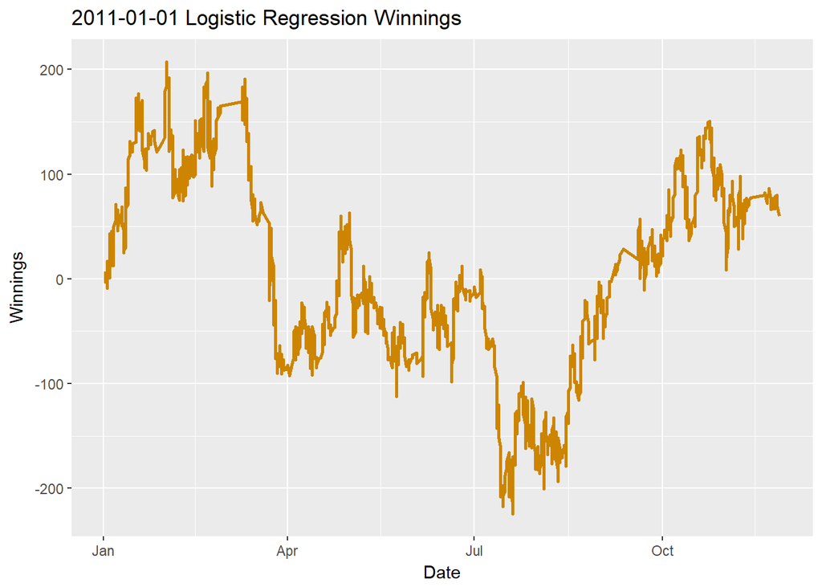

```
##   test.start.date        method count net.profit successful.bets
## 1      2011-01-01 Random Forest  2664      -46.4            1820
## 2      2011-01-01           SVM  2664      279.4            1922
## 3      2011-01-01       Log reg  2664       59.8            1897
## 4      2011-01-01         Boost  2664      469.9            1840
##   success.rate average.payout
## 1    0.6831832    -0.01741742
## 2    0.7214715     0.10487988
## 3    0.7120871     0.02244745
## 4    0.6906907     0.17638889
## [1] "2012-01-01"
```

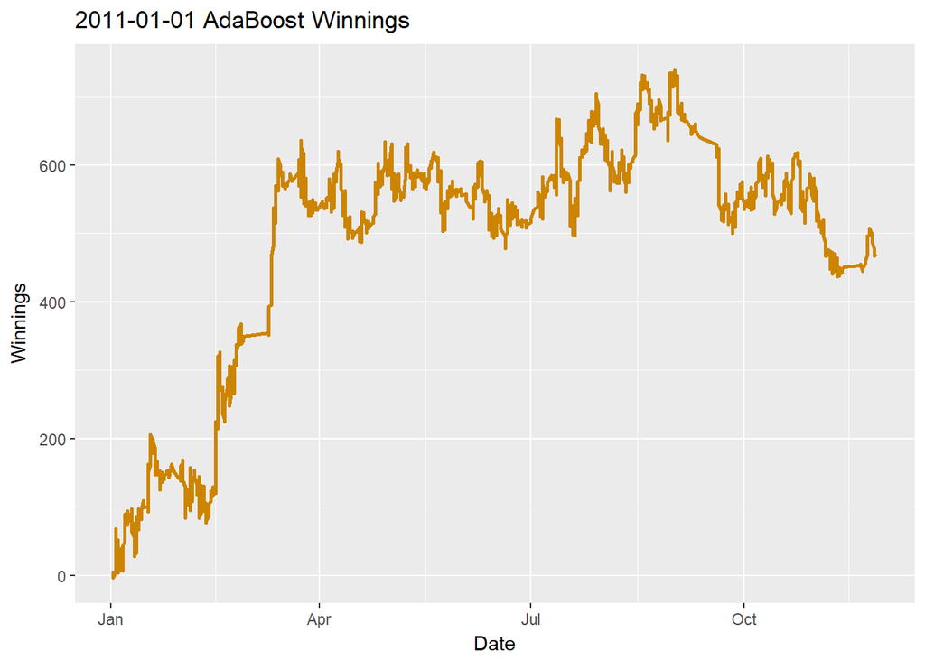

```
## [1] "reg"
##
##                       FALSE TRUE
##   False: Underdog Won    10  736
##   True: Favorite Won      7 1918
## [1] "accuracy:  0.721827031074504"
## [1] "svm"
##
##                       FALSE TRUE
##   False: Underdog Won     3  743
##   True: Favorite Won      1 1924
## [1] 0.7214526
## [1] "rf"
##
##                       FALSE TRUE
##   False: Underdog Won   150  596
##   True: Favorite Won    217 1708
## [1] 0.6956196
## [1] "boost"
##
##                       FALSE TRUE
##   False: Underdog Won   196  550
##   True: Favorite Won    333 1592
## [1] "accuracy:  0.669412205166604"
##
##                       FALSE TRUE
##   False: Underdog Won   196  550
##   True: Favorite Won    333 1592
```

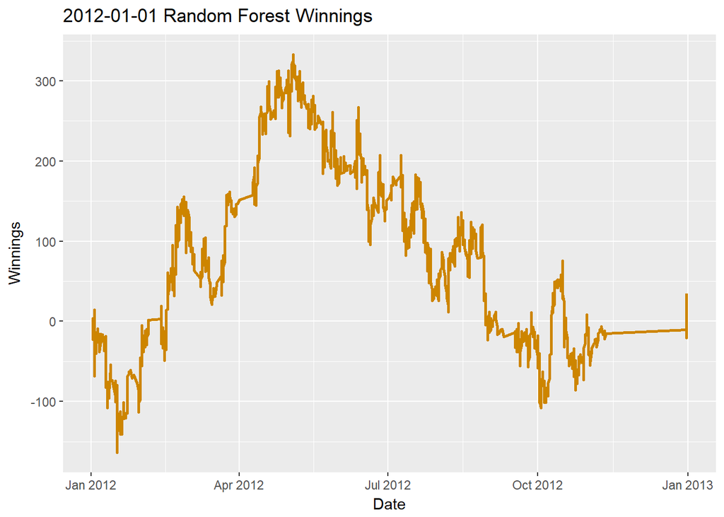

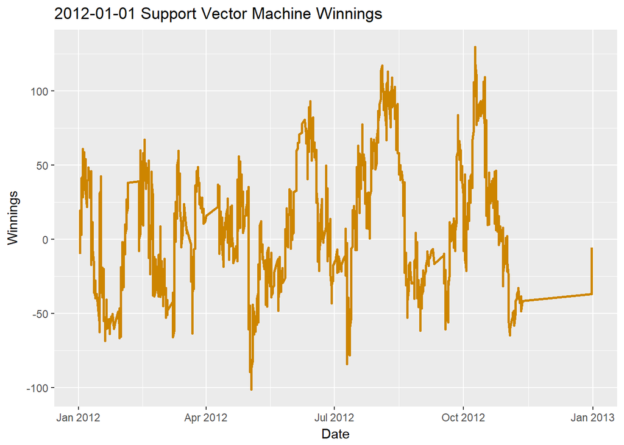

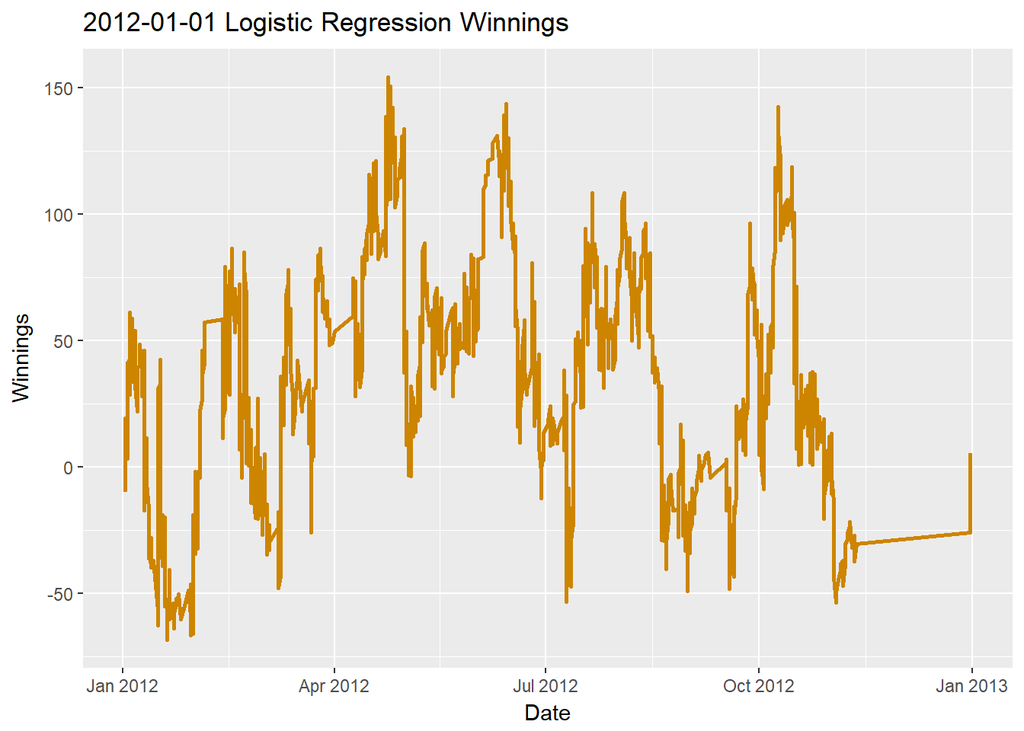

```
##   test.start.date        method count net.profit successful.bets
## 1      2012-01-01 Random Forest  2671       34.8            1858
## 2      2012-01-01           SVM  2671       -5.7            1927
## 3      2012-01-01       Log reg  2671        5.5            1928
## 4      2012-01-01         Boost  2671     -617.3            1788
##   success.rate average.payout
## 1    0.6956196    0.013028828
## 2    0.7214526   -0.002134032
## 3    0.7218270    0.002059154
## 4    0.6694122   -0.231111943
## [1] "2013-01-01"
```

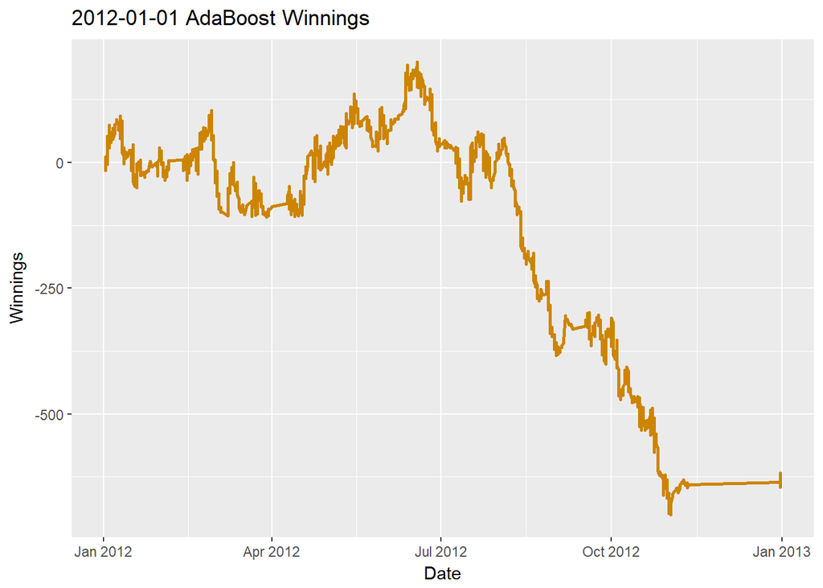

```
## [1] "reg"
##
##                       FALSE TRUE
##   False: Underdog Won    24  753
##   True: Favorite Won     12 1770
## [1] "accuracy:  0.7010550996483"
## [1] "svm"
##
##                       FALSE TRUE
##   False: Underdog Won     0  777
##   True: Favorite Won      0 1782
## [1] 0.6963658
## [1] "rf"
##
##                       FALSE TRUE
##   False: Underdog Won   245  532
##   True: Favorite Won    383 1399
## [1] 0.6424385
## [1] "boost"
##
##                       FALSE TRUE
##   False: Underdog Won   212  565
##   True: Favorite Won    334 1448
## [1] "accuracy:  0.648690894880813"
##
##                       FALSE TRUE
##   False: Underdog Won   212  565
##   True: Favorite Won    334 1448
```

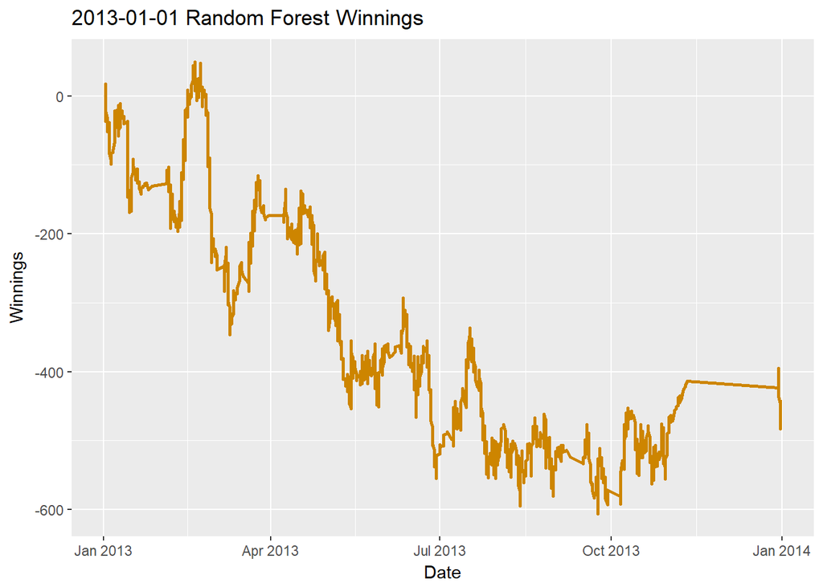

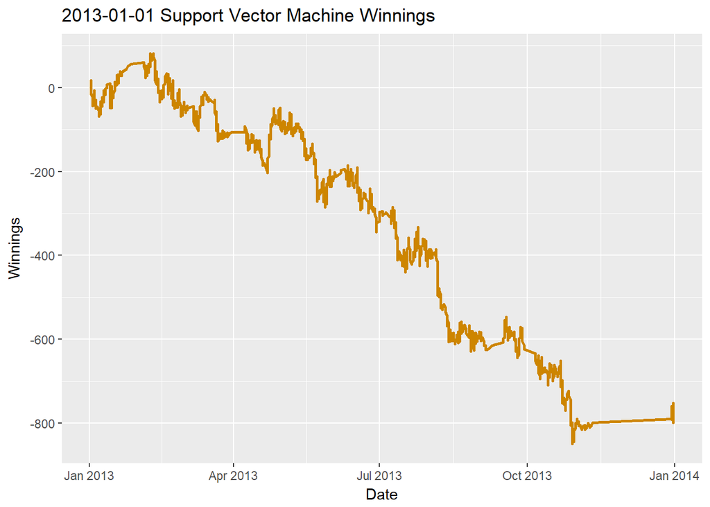

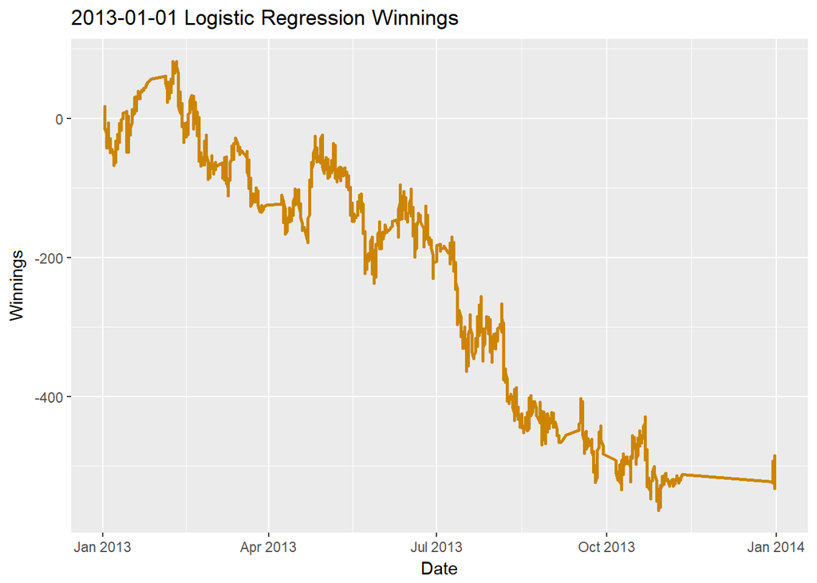

```
##   test.start.date        method count net.profit successful.bets
## 1      2013-01-01 Random Forest  2559     -441.1            1644
## 2      2013-01-01           SVM  2559     -787.2            1782
## 3      2013-01-01       Log reg  2559     -520.1            1794
## 4      2013-01-01         Boost  2559     -561.7            1660
##   success.rate average.payout
## 1    0.6424385     -0.1723720
## 2    0.6963658     -0.3076202
## 3    0.7010551     -0.2032435
## 4    0.6486909     -0.2194998
## [1] "2014-01-01"
```

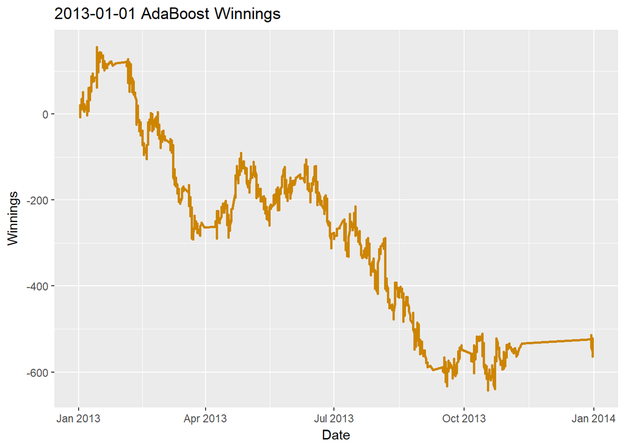

```
## [1] "reg"
##
##                       FALSE TRUE
##   False: Underdog Won    79  658
##   True: Favorite Won     94 1710
## [1] "accuracy:  0.70405352223534"
## [1] "svm"
##
##                       FALSE TRUE
##   False: Underdog Won     0  737
##   True: Favorite Won      0 1804
## [1] 0.7099567
## [1] "rf"
##
##                       FALSE TRUE
##   False: Underdog Won   175  562
##   True: Favorite Won    262 1542
## [1] 0.6757182
## [1] "boost"
##
##                       FALSE TRUE
##   False: Underdog Won   117  620
##   True: Favorite Won    168 1636
## [1] "accuracy:  0.689885871704054"
##
##                       FALSE TRUE
##   False: Underdog Won   117  620
##   True: Favorite Won    168 1636
```

[16 more figures not shown]

```
##   test.start.date        method count net.profit successful.bets
## 1      2017-01-01 Random Forest  2606     -655.0            1682
## 2      2017-01-01           SVM  2606    -1089.9            1767
## 3      2017-01-01       Log reg  2606    -1264.2            1750
## 4      2017-01-01         Boost  2606     -548.8            1660
##   success.rate average.payout
## 1    0.6454336     -0.2513431
## 2    0.6780507     -0.4182272
## 3    0.6715272     -0.4851113
## 4    0.6369916     -0.2105909
```

```r
#create lists to keep track of the final payout each year
rf.final.payouts = c()
svm.final.payouts =c()
reg.final.payouts = c()
boost.final.payouts = c()

#starting in 2011 because some data causes trouble before this year.
for(i in 2011:2017){
  #create date strings to use to limit training and testing datasets
  train.start.date <-  paste0(i-3, "-01-01", sep = '')
  train.end.date <- paste0(i-1, "-01-01", sep = '')
  test.start.date <- paste0(i, "-01-01", sep = '')
  test.end.date <- paste0(i+1, "-01-01", sep = '')

  #view year start of testing set
  print(test.start.date)

  #create training and testing dataset
  new.train <- imputed.data %>% dplyr::filter(date.new < as.Date(train.end.date), date.new >= as.Date(train.start.date))
  test.data <- imputed.data %>% dplyr::filter(date.new > as.Date(test.start.date), date.new < as.Date(test.end.date))

  #Make predictive models

  rf.model = randomForest(favorite_won~., data=new.train, ntree=20, proximity=T)

  #SVM
  svm.model <- svm(favorite_won~., data = new.train)

  #Log Reg
  reg.model <- glm(favorite_won ~.,family=binomial(link='logit'),data=new.train)

  #Addaboost
  boost.model <- adaboost(favorite_won ~., new.train, nIter = 20)


  #Get boolean true false whether model predicts an upset or not
  rf.prediction = predict(rf.model, newdata=test.data)
  svm.prediction <- predict(svm.model, test.data)
  reg.prediction <- as.factor(predict(reg.model, test.data, type = "response") > .5)
  boost.prediction <- predict( boost.model,test.data)$class


  #Make data with prediction column for each match

  #random forest
  rf.pred <- test.data
  rf.pred$prediction <- rf.prediction

  #SVM
  svm.pred <- test.data
  svm.pred$prediction <- svm.prediction

  #Log Regression
  reg.pred <- test.data
  reg.pred$prediction <- reg.prediction


  #Addaboost
  boost.pred <- test.data
  boost.pred$prediction <- boost.prediction

  test.data$print_favorite_won = ifelse(test.data$favorite_won == "TRUE", "True: Favorite Won", "False: Underdog Won")
  print("reg")
  CM = table(test.data$print_favorite_won, reg.pred$prediction)
  accuracy = (sum(diag(CM)))/sum(CM)
  print(CM)
  print(paste("accuracy: ",accuracy ))


  print("svm")

  CM = table(test.data$print_favorite_won, svm.pred$prediction)
  accuracy = (sum(diag(CM)))/sum(CM)
  print(CM)
  print(accuracy)

  print("rf")
  CM = table(test.data$print_favorite_won, rf.pred$prediction)
  accuracy = (sum(diag(CM)))/sum(CM)
  print(CM)
  print(accuracy)


  print("boost")
  CM = table(test.data$print_favorite_won, boost.pred$prediction)
  accuracy = (sum(diag(CM)))/sum(CM)
  print(CM)
  print(paste("accuracy: ",accuracy ))
  print(CM)


  #make bets for each model
  bet <- 10
  rf.bets <- rf.pred %>% mutate( winnings = case_when(prediction != favorite_won ~-bet,
                                             prediction == "TRUE" & favorite_won == prediction  ~ bet * (FMaxOdds -1),
                                             prediction == "FALSE" & favorite_won == prediction ~ bet * (UMaxOdds -1),
                                             TRUE ~ NA_real_))
  svm.bets <- svm.pred %>% mutate( winnings = case_when(prediction != favorite_won ~-bet,
                                             prediction == "TRUE" & favorite_won == prediction  ~ bet * (FMaxOdds -1),
                                             prediction == "FALSE" & favorite_won == prediction ~ bet * (UMaxOdds -1),
                                             TRUE ~ NA_real_))
  reg.bets <- reg.pred %>% mutate( winnings = case_when(prediction != favorite_won ~-bet,
                                             prediction == "TRUE" & favorite_won == prediction  ~ bet * (FMaxOdds -1),
                                             prediction == "FALSE" & favorite_won == prediction ~ bet * (UMaxOdds -1),
                                             TRUE ~ NA_real_))
  boost.bets <- boost.pred %>% mutate( winnings = case_when(prediction != favorite_won ~-bet,
                                             prediction == "TRUE" & favorite_won == prediction  ~ bet * (FMaxOdds -1),
                                             prediction == "FALSE" & favorite_won == prediction ~ bet * (UMaxOdds -1),
                                             TRUE ~ NA_real_))


  #Plot winnings over time for each model

  plot.winnings(rf.bets, paste(test.start.date, "Random Forest Winnings"))
  plot.winnings(svm.bets, paste(test.start.date, "Support Vector Machine Winnings"))
  plot.winnings(reg.bets, paste(test.start.date, "Logistic Regression Winnings"))
  plot.winnings(boost.bets, paste(test.start.date, "AdaBoost Winnings"))

  #append final payouts
  rf.final.payouts <-  c(rf.final.payouts, sum(rf.bets$winnings))
  svm.final.payouts <-  c(svm.final.payouts, sum(svm.bets$winnings))
  reg.final.payouts <-  c(reg.final.payouts, sum(reg.bets$winnings))
  boost.final.payouts <-  c(boost.final.payouts, sum(boost.bets$winnings))

  #make aggregate table
  agg.table <- rf.bets %>% summarise(test.start.date =test.start.date, method = "Random Forest",count = n(), net.profit = sum(winnings), successful.bets = sum(rf.bets$prediction == rf.bets$favorite_won))
  agg.table <- agg.table %>%
     rbind(svm.bets  %>% summarise(test.start.date =test.start.date, method = "SVM",count = n(), net.profit = sum(winnings), successful.bets = sum(svm.bets$prediction ==svm.bets$favorite_won))) %>%
    rbind(reg.bets  %>% summarise(test.start.date =test.start.date, method = "Log reg",count = n(), net.profit = sum(winnings), successful.bets = sum(reg.bets$prediction ==reg.bets$favorite_won))) %>%
  rbind(boost.bets  %>% summarise(test.start.date =test.start.date, method = "Boost",count = n(), net.profit = sum(winnings), successful.bets = sum(boost.bets$prediction ==boost.bets$favorite_won)))

  agg.table <- agg.table %>%mutate(success.rate = successful.bets / count, average.payout = net.profit / count)
  print(agg.table)
}
```

```r
final.payouts <- data.frame(random.forest = rf.final.payouts, svm = svm.final.payouts, log.reg = reg.final.payouts, ada.boost = boost.final.payouts)

final.payouts
```

```
##   random.forest     svm log.reg ada.boost
## 1         -46.4   279.4    59.8     469.9
## 2          34.8    -5.7     5.5    -617.3
## 3        -441.1  -787.2  -520.1    -561.7
## 4         102.3   -52.6  -167.8     189.5
## 5        -624.3  -277.9  -278.5    -390.9
## 6        -261.7  -115.8  -140.1    -463.3
## 7        -655.0 -1089.9 -1264.2    -548.8
```

# Use Models to predict how much money you will win if you bet on favorite or underdog

First we need to change imputed data for our new prediction column

```r
#create new dataframe to impute
imputed.data <- men.data

#add favorite_won column used to predict winner
imputed.data$favorite_won <- as.factor(!imputed.data$odds.upset)

#Convert characters to factors
character.columns <- c("Location", "Tournament", "Series", "Surface", "Court","Round" )
for(col.name in character.columns){
  imputed.data[[col.name]]<- as.factor(imputed.data[[col.name]])
}

#List of odds books columns
favorite.columns <- c("B365F", "B.WF" , "CBF" , "EXF" , "LBF" , "GBF" , "IWF" , "PSF" , "SBF" , "SJF" , "UBF" )
underdog.columns <- c("B365U", "B.WU" , "CBU" , "EXU" , "LBU" , "GBU" , "IWU" , "PSU" , "SBU" , "SJU" , "UBU")

#replace all null value books with the average over all books for that match
for(col.name in favorite.columns){
  imputed.data[[col.name]][is.na(imputed.data[[col.name]])] <- imputed.data[["avgF"]][is.na(imputed.data[[col.name]])]
}
for(col.name in underdog.columns){
  imputed.data[[col.name]][is.na(imputed.data[[col.name]])] <- imputed.data[["avgU"]][is.na(imputed.data[[col.name]])]
}

#remove any remaining null values, and grab only the columns that we can use in our models
imputed.data <- imputed.data %>% na.omit() %>% select(-maxWinOdds, -minLoseOdds, -maxProfit, -rank.upset, -odds.upset, -Tournament, -Location)
#create a column for rank difference
imputed.data <- imputed.data %>% mutate(rank.diff = abs( URank - FRank))

#note if you change this vaue here and not above, it will be difficult to compare between methods
bet <- 10

#make payout columns and select columns ou need
imputed.data <- imputed.data %>% na.omit() %>% mutate(payout.favorite = case_when(favorite_won == "TRUE"  ~ bet * ( FMaxOdds - 1), favorite_won =="FALSE" ~ -bet, TRUE ~ NA_real_), payout.underdog = case_when(favorite_won == "FALSE"  ~ bet * ( UMaxOdds - 1), favorite_won =="TRUE" ~ -bet, TRUE ~ NA_real_))

# choose payout column to be the underdog(can switch to favorite in mutate)
imputed.data <- imputed.data %>% mutate(payout = payout.underdog) %>% select(-payout.favorite, -payout.underdog, -favorite_won)

#view new data
str(imputed.data)
```

```
## 'data.frame':    45641 obs. of  41 variables:
##  $ ATP       : int  1 1 1 1 1 1 1 1 1 1 ...
##  $ Series    : Factor w/ 9 levels "ATP250","ATP500",..: 4 4 4 4 4 4 4 4 4 4 ...
##  $ Court     : Factor w/ 2 levels "Indoor","Outdoor": 2 2 2 2 2 2 2 2 2 2 ...
##  $ Surface   : Factor w/ 4 levels "Carpet","Clay",..: 4 4 4 4 4 4 4 4 4 4 ...
##  $ Round     : Factor w/ 8 levels "1st Round","2nd Round",..: 1 1 2 2 2 2 5 5 5 5 ...
##  $ Best.of   : Factor w/ 2 levels "3","5": 1 1 1 1 1 1 1 1 1 1 ...
##  $ year      : num  2001 2001 2001 2001 2001 ...
##  $ date.new  : Date, format: "2001-01-01" "2001-01-01" ...
##  $ B365F     : num  1.11 1.2 1.28 1.13 1.43 ...
##  $ B.WF      : num  1.11 1.2 1.28 1.13 1.43 ...
##  $ CBF       : num  1.11 1.28 1.35 1.13 1.42 1.55 1.53 1.4 1.7 1.35 ...
##  $ EXF       : num  1.11 1.2 1.28 1.13 1.43 ...
##  $ LBF       : num  1.11 1.2 1.28 1.13 1.43 ...
##  $ GBF       : num  1.12 1.12 1.2 1.13 1.41 ...
```

[output cut: 27 more lines]